# Tree species richness and water availability interact to affect soil microbial processes - ScienceDirect

## Figures (4)

[figure not shown]

[figure not shown]

## Tables (4)

1. Table 1
2. Table 2
3. Table 3
4. Table 4

## Extras (1)

1. Document

## [Soil Biology and Biochemistry](https://www.sciencedirect.com/science/journal/00380717)

Available online 11 February 2021, 108180

[In Press, Journal Pre-proof](https://www.sciencedirect.com/science/journal/aip/00380717)

# Tree species richness and water availability interact to affect soil microbial processes

[ManuellaStrukelj<sup>1</sup>](https://www.sciencedirect.com/science/article/pii/S0038071721000523#!)[WilliamParker<sup>2</sup>](https://www.sciencedirect.com/science/article/pii/S0038071721000523#!)[EmmanuelCorcket<sup>3</sup>](https://www.sciencedirect.com/science/article/pii/S0038071721000523#!)[LaurentAugusto<sup>4</sup>](https://www.sciencedirect.com/science/article/pii/S0038071721000523#!)[RimKhlifa<sup>5</sup><sup>6</sup>](https://www.sciencedirect.com/science/article/pii/S0038071721000523#!)[HervéJactel<sup>7</sup>](https://www.sciencedirect.com/science/article/pii/S0038071721000523#!)[Alison D.Munson<sup>1</sup>](https://www.sciencedirect.com/science/article/pii/S0038071721000523#!)

https://doi.org/10.1016/j.soilbio.2021.108180[Get rights and content](https://s100.copyright.com/AppDispatchServlet?publisherName=ELS&contentID=S0038071721000523&orderBeanReset=true)

## Highlights

**•**

Soil was sampled in 2 tree diversity experiments that also manipulated water supply.

**•**

Microbial biomass increased with diversity, but only under high water availability.

**•**

Soil organic carbon was not affected by tree diversity nor by water availability.

**•**

Tree diversity impacted soil through microbial functional diversity and temperature.

**•**

Future research should consider functional traits of trees and larger food web.

## Abstract

The objective of this study was to examine the interactive influence of tree diversity and water availability on microbial functioning in surface soil (0-10 cm). The study was conducted at IDENT-SSM (age 4.2 years) and ORPHEE (age 9.0 years), two field experiments of the TreeDivNet platform that established plantations with a gradient of tree species richness exposed to high and low water availability treatments. Soil microbial biomass, activity, functional diversity and functional identity were estimated using the MicroResp<sup>TM</sup> method. Soil organic carbon and several other variables potentially associated with soil processes (soil moisture, soil and air temperature, soil pH, soil C:N ratio, tree biomass) were also measured. Our results indicate that tree species richness significantly increased soil microbial biomass and, to a lesser extent, soil microbial activity in the high water availability treatment, at both trial sites. However, tree species richness effects on microbial processes were not expressed in the low water availability treatment, contrary to the stress-gradient hypothesis. Tree species richness and water treatment interaction impacted microbial biomass and activity through their effects on microbial functional diversity and identity at IDENT-SSM and air temperature at ORPHEE. In conclusion, the mechanisms through which tree diversity creates bottom-up effects on biological soil processes depend on environmental conditions and time following the establishment of tree communities. Future research relating diversity and water availability effects on soil microbial processes should consider functional traits of tree species and a larger range of trophic levels including herbivores and soil fauna to better understand biodiversity-soil ecosystem function relationships in forest ecosystems.

## Key words

microbial activity

soil carbon

Microresp

functional diversity

biodiversity experiments

drought

## 1. Introduction

The composition and diversity of soil microbial communities and their ability to degrade a variety of organic compounds are central to maintaining soil productivity and stability (Schimel and Schaeffer, 2012; De Vries and Shade, 2013; Wagg et al., 2014; Shihan et al., 2017), particularly in forest ecosystems that contain about 50% of the world’s terrestrial organic carbon (C) stocks (Shvidenko et al., 2005). Soil moisture has a strong influence on microbial activity (Manzoni et al., 2012; Moyano et al., 2013) and precipitation regime will be considerably altered during projected climatic change due to more frequent and severe drought events (Dai et al., 2011). In a time of global expansion of forest plantations for wood production, a reevaluation of forestry practices is required to better mitigate and adapt plantations to climate change, in order to sustain the provision of wood and other ecological goods and services (Paquette and Messier, 2010; Payn et al., 2015). Establishment of mixed-species rather than monoculture plantations is one management option proposed to enhance tree productivity, C sequestration, and resistance and resilience to the increasing biotic and abiotic disturbance pressures (Paquette and Messier, 2010; Dai et al., 2011; Bauhus et al., 2017; Jactel et al., 2017). Understanding how the interaction of tree species diversity and water availability impacts soil microbial processes is essential to increased, informed use of mixed species plantations for these services.

Tree diversity has been found to have a positive effect on microbial biomass and activity (Thoms et al., 2010; Khlifa et al., 2017). This positive effect may follow from: (1) increased tree productivity (Paquette and Messier, 2011; Liang et al., 2016) that provides more above and belowground litter to enhance soil C (Mayer et al., 2020), microbial growth (Zak et al., 2003) and a potential “priming” effect (i.e., enhanced decomposition of persistent soil organic matter; Fontaine et al., 2007); (2) diversification of the quality of above and belowground litter, root exudates and microhabitats that enhances the diversity in composition and functions of microbial communities (Hooper et al., 2000; Hättenschwiler et al., 2005; Shihan et al., 2017; Liu et al., 2020); and (3) improved soil nutrient status and pH and regulated microclimate (Vogel et al., 2013; Eisenhauer et al., 2010; Thoms et al., 2010). This positive effect of species richness may decline at higher levels due to functional redundancy, i.e., different species performing the same functional role and being substitutable to each other, with therefore little impact on ecosystem functioning (Rosenfeld, 2002). Alternatively, positive diversity effects may not be observed when tree species identity, rather than tree species diversity, is a stronger driver of microbial processes (Scheibe et al., 2015). Therefore, the underlying mechanisms through which tree diversity effects microbial processes need to be further investigated under different environmental conditions.

In cases of reduced precipitation, water-limited conditions generally lead to decreased microbial activity and biomass (Manzoni et al., 2012; Bastida et al., 2017; Vogel et al., 2013). This can be caused by direct effects of reducing soil moisture, which modifies resources diffusion and physiology of microbial communities (Manzoni et al., 2012; Moyano et al., 2013). Reducing precipitation can also indirectly affect soil microorganisms through decreasing tree growth and soil C inputs, and changing understorey vegetation, microclimate, and microbial community composition and functions (Schimel et al., 2007; MacKay et al., 2012; Zhou et al., 2016; Bastida et al., 2017; Corcket et al. 2020). Particularly, changes from bacteria-dominated communities to a greater abundance of drought-tolerant species, typically fungi and actinomycetes (Manzoni et al., 2012), should be associated with higher abilities to catabolize lignin-derived compounds (De Boer et al., 2005). Increased ability to use carboxylic acids in dry environments has also been observed (Sherman and Steinberger, 2012). According to the stress-gradient hypothesis, positive plant diversity effects on ecosystem functions are predicted to be more strongly expressed in more stressed, less productive environments due to a relative increase in the importance of complementarity interactions (Maestre et al., 2009; He et al., 2013; Ratcliffe et al., 2017). The validity of this hypothesis has been demonstrated for tree productivity (e.g., Paquette and Messier, 2011) but not soil processes (Vogel et al., 2013; Thakur et al., 2015). Clearly, detailed field research is necessary to better understand how tree diversity effects on soil organic matter dynamics vary with water availability conditions.

TreeDivNet (https://treedivnet.ugent.be/index.html) is an international research platform consisting of 27 field experiments designed to study the effects of tree diversity on ecosystem functioning (Verheyen et al., 2016). Previous research has focused on diversity effects on aboveground biomass production and the incidence of biotic disturbance (Grossman et al., 2018). Although tree diversity effects on soil processes have been reported (Archambault et al., 2019; Jewell et al., 2017; Khlifa et al., 2017), the potential modulation of tree diversity effects on soil processes by environmental gradients in soil moisture availability has not been examined.

The objective of this study was to analyze how tree species richness and water availability conditions influence soil microbial biomass and activity, through microbial functional diversity and functional identity, soil properties (C, pH, C:N ratio, moisture), temperature and tree biomass, at two field experiments that exposed monocultures and mixtures to manipulated conditions of high and low growing season water availability. The MicroResp<sup>TM</sup> method was used to assess microbial processes. This is a widely used approach to determine the community level physiological profile of soil microbial communities, based on their metabolic capacity to utilize different organic substrates characteristic of root exudates and plant litter (Campbell et al., 1997; Campbell et al., 2003). Microbial functional diversity and identity correspond respectively to the diversity and the quality of substrates that were catabolized. We tested the following four hypotheses:

**1.**

**Tree species richness effect hypothesis:** Increased tree species richness will have a positive effect on soil microbial biomass and activity, regardless of water availability conditions, but this positive effect will decline at higher levels of species richness due to functional redundancy. Moreover, increased tree species richness will be associated with higher microbial functional diversity and higher soil C but will not influence microbial functional identity.

**2.**

**Water availability hypothesis:** Lower water availability will decrease soil microbial biomass and activity. Lower water availability will also decrease soil C and affect microbial functional identity towards greater abilities to catabolize carboxylic and aromatic acids.

**3.**

**Interactions effect hypothesis:** In accordance with the stress-gradient hypothesis, the effect of tree species richness on soil processes will be more strongly expressed under low than high water availability conditions.

**4.**

**Mechanisms hypothesis:** Tree species richness will influence soil microbial biomass and activity through its effects on tree biomass production, soil C, soil microbial functional diversity, microclimate, soil pH, and soil C to nitrogen ratio (C:N). These species richness effects will differ with water availability conditions, due to the impact of water availability on tree biomass production, soil C, microclimate, and microbial functional identity.

## 2. Materials and methods

### 2.1. Tree diversity experiments

This study was conducted at the International Diversity Experiment Network with Trees (IDENT) at Sault Sainte Marie, Ontario, Canada (IDENT-SSM) (Belluau et al., 2020) and the ORPHEE experiment at Bordeaux, France (Castagneyrol et al., 2018) (Table 1, Fig. S1).

Table 1. Site characteristics, experimental design and sampling 1 protocol of the IDENT-SSM and 2 ORPHEE tree diversity experiments

|  | IDENT-SSM | ORPHEE |
| --- | --- | --- |
| Site |  |  |
| - Location | Sault Sainte Marie, Canada | Bordeaux, France |
|  | Lat. 46.52°, Long. -84.34°, Alt. 210 m asl | Lat. 44.67°, Long. -0.77°, Alt. 60 m asl |
| - Climate | Mean annual temperature = 4.7°C | Mean annual temperature = 12.7°C |
|  | Mean annual precipitation = 897 mm | Mean annual precipitation = 876 mm |
| - Soil type | Moderately infertile sandy loam cambisol on glacio-lacustrine deposits | Highly infertile sandy podzol on Aeolian sand sediments |
| **Experimental design** |  |  |
| - Year of establishment | 2013 | 2008 |
| - Plot size | 3.2 x 3.2 m (7 x 7 trees) | 20 x 20 m (10 x 10 trees) |
| - Water availability treatment (WT) | - Rainfall exclusion (Low WT) | - No irrigation (Low WT) |
|  | - Irrigation (High WT) | - Irrigation (High WT) |
| - Randomizations | (1) WT applied to blocks | (1) WT applied to blocks |
|  | (2) within-block species mixtures | (2) within-block species mixtures |
|  | (3) within-plot tree species | (3) regular alternate pattern of tree species within-plot |
| **Sampling protocol** |  |  |
| - Blocks | 8 (4 low and 4 high WT) | 6 (3 low and 3 high WT) |
| - Monocultures (SR1) | - *Betula papyrifera* (Ba) |  |
|  | - *Quercus rubra* (Qu) | - *Betula pendula* (Be) |
|  | - *Picea glauca* (Pg) | - *Quercus robur* (Qo) |
|  | - *Pinus strobus* (Ps) | - *Pinus pinaster* (Pp) |
| - Mixtures | 4 mixtures of SR2: |  |
|  | - Pg x Ps | 3 mixtures of SR2: |
|  | - Ba x Ps | - Be x Qo |
|  | - Qu x Pg | - Be x Pp |
|  | - Qu x Ps | - Qo x Pp |
|  | 1 mixture of SR4: | 1 mixture of SR3: |
|  | - Qu x Ba x Pg x Ps | - Be x Qo x Pp |
| - Date | July 2017 | January 2017 |

The IDENT-SSM experiment was established in 2013 in an area of marginal pasture on abandoned agricultural land. Soils are classified as Eutric Arenosols in the WRB system (IUSS Working Group WRB, 2014), or Eluviated Dystric Brunisols in the Canadian classification (Soil Classification Working Group, 1998). The soil is well-drained, relatively infertile and loamy sand in texture with the presence of gravel (> 2mm) throughout the profile. Due to soil fertility concerns, the trial area of 1 ha was amended prior to planting with calcitic lime (3 t∙ha<sup>-1</sup>) and a topical application of slow release fertilizer (Nutricote® 14-14-14, 1.5 t∙ha<sup>-1</sup>). The area was planted with one-year-old seedlings of six native species: *Acer saccharum* Marsh. (As), *Betula papyrifera* Marsh. (Ba), *Quercus rubra* L. (Qu), *Larix laricina* (Du Roi) K. Koch (Ll), *Pinus strobus* L. (Ps), and *Picea glauca* (Moench) Voss (Pg). Seedlings were planted at 0.4 m spacing in square, 10.24 m<sup>2</sup> plots (7 rows of 7 trees) as monocultures and 16 assorted 2, 4 and 6 species combinations randomly arranged within eight experimental blocks (Figs. S1, S2). Plots were maintained free of other forms of vegetation.

The ORPHEE experiment was established in 2008 by harvesting, clearing stumps and ploughing an area occupied by a maritime pine (*Pinus pinaster* Ait.) stand. The soil is classified as an Entic Ortsteinic Podzol in the WRB system (IUSS Working Group WRB, 2014) and Podzosol humo-duriques in the French classification (Baize and Girard, 2009). The texture is very coarse (>90% sand) and free of gravel. Drainage is rapid in the upper soil profile but with a water table that varies seasonally at a depth of 0.5-2.0 m. Drainage ditches were established to prevent the site from flooding in the winter (Fig. S1). The trial area of 12 ha was fertilized with phosphorus and potassium (120 units∙ha<sup>-1</sup>) to limit the risk of plantation failure that could be induced by the extreme low fertility of the local soils, particularly in phosphorus (Achat et al., 2009). The plantation was carried out using one-year-old seedlings of five native species: *Betula pendula* Roth (Be), *Quercus robur* L. (Qo), *Quercus pyrenaica* Willd. (Qp), *Quercus ilex* L. (Qi), and *Pinus pinaster* Ait. (Pp). Seedlings were planted at 2 m spacing in square, 400 m<sup>2</sup> plots (10 rows of 10 trees) as monocultures and all possible 2, 3, 4 and 5 species combinations, for a total of 31 different mixtures (Figs. S1, S2). Eight experimental blocks were established, each containing one plot of each mixture with an additional replication of the five species composition. Understorey vegetation was not controlled prior to our sampling, and was dominated by *Molinia caerulea*, *Ulex minor* and *Pteridium aquilinum* (Corcket et al., 2020).

At both experimental sites, four blocks were exposed to either a high or low water availability treatment (Fig. S3, hereto referred to as high and low water treatments). The high water treatment was created by irrigation during the growing season. The low water treatment was created either by a rainfall exclusion system (IDENT-SSM, Fig. S4) or by natural growing season drought events (ORPHEE; sandy site with frequent dry summers). At IDENT-SSM, irrigation and rainfall exclusion treatments began in June 2014. Weekly irrigation provided the equivalent of ca. 2.5 cm of rain from June 1-August 31, an amount equivalent to 130% of normal precipitation. At ORPHEE, daily irrigation occurred from early May to late September 2015 and 2016 provided ca. 3.0 mm of water overnight. This amount of water corresponds to 60% of total annual precipitation. Because of the generally warm, dry summer period and the sandy, rapidly drained soil at both trial sites, plants generally experienced climatic moisture deficits over much of the growing season (Castagneyrol et al., 2018; Belluau et al., 2020). At ORPHEE, the summer of 2016 was one of the driest recorded since 1959 ([www.meteofrance.fr](http://www.meteofrance.fr/)).

At IDENT-SSM, the present study was performed in four monocultures of Ba, Qu, Ps, and Pg (SR1), four of their 2-species-mixtures (SR2), and their 4-species-mixture (SR4) in all eight blocks. At ORPHEE, three monocultures of Be, Qo, and Pp (SR1), their three 2-species-mixtures (SR2), and their 3-species-mixture (SR3) were studied in 3 blocks of each water treatment (Table 1, Figs. S1, S2).

### 2.2. Tree measurements

Tree diameter and height were measured during the fall of 2016 at both sites. Total aboveground tree biomass (tree biomass, hereafter) was estimated using site-derived allometric equations that were based on basal stem diameter at IDENT-SSM (Belluau et al., 2020). Generalized biomass equations, based on diameter at breast height and height for Pp and Be species, and only height for Qo species, were used at ORPHEE (Annigh öfer et al., 2016; Shaiek et al., 2011).

### 2.3. Soil sampling and processing

After removal of the O horizon, which was mainly composed of a layer of slightly decomposed litter at both sites, the upper 10 cm of mineral soil was systematically sampled at interior of plots to avoid edge and neighborhood effects, using a 5 cm outside diameter stainless steel soil core sampler. At IDENT-SSM, four soil cores per plot were collected in summer 2017 (age 4.2 years) and combined into a single composite sample for each of 72 plots. At ORPHEE, twelve cores were collected per plot in winter 2017 (age 9.0 years) and combined for each of 42 plots (Table 1, Fig. S1). The coring attachment was disinfected between plots. Soil samples were stored on ice in a cooler during field work and at 4°C for one week prior to processing.

Gravel and roots were removed from each soil sample using a sterilized 2 mm mesh sieve. A sub-sample for each plot was stored at 4°C to measure field-moist soil moisture content and water holding capacity. A second sub-sample was allowed to dry at room temperature (∼22°C) to constant mass (∼7 days) to determine air-dried soil moisture content, texture, pH, C, and N, and for use in microbial analyses.

### 2.4. Soil physical and chemical analyses

Gravimetric soil moisture content of both sub-samples was determined after drying to constant mass at 105°C (∼48 h). Soil water holding capacity was measured as the mass of water retained after saturating the sub-sample for 30 min, and after allowing it to drain for 30 min. Soil pH was measured with a pH meter in a 1:2 soil-to-CaCl<sub>2</sub> (0.01 M) ratio. Total soil C, N and C:N were determined by high temperature combustion followed by thermo-conductimetric detection with a CNS Analyser (Trumac CNS, LECO). Concentration of soil organic C (mg·g<sup>-1</sup>) was assumed to be equal to the total soil C concentration because soil at both sites contained no carbonates.

### 2.5. Soil microbial analyses

The MicroResp<sup>TM</sup> procedure used in this study followed the method of Campbell et al. (2003), Khlifa et al. (2017) and Shihan et al. (2017) (Appendix S1). Microbial respiration after addition of water (basal respiration, BR), glucose (glucose-induced respiration, GIR) or other 14 organic substrates (substrate-induced respiration, SIR, see substrates in Appendix S1) was estimated by converting the normalized 6-hour absorbance values to a CO<sub>2</sub> efflux rate (μg CO<sub>2</sub>·g<sup>-1</sup>·h<sup>-1</sup>) based on a calibration curve (Campbell et al., 2003; Khlifa et al., 2017). Microbial activity and biomass were estimated by BR and GIR (Anderson and Domsch, 1978), respectively. For estimations of soil microbial functional diversity and identity, the SIR of each substrate was corrected by subtracting the BR value. Functional diversity of each plot soil sample was estimated by the Shannon-Weaver diversity index (*H’*)(1)$H′=∑i=115Pi·ln(Pi)$where *Pi* is the proportion of the corrected SIR of the *i*<sup>th</sup> substrate relative to the sum of corrected SIR for all 14 substrates (Zak et al., 1994). Functional identity was defined by two indices of the ability of microbial communities to catabolize specific organic compounds relatively to other compounds. The first, “microbial respiration of carboxylic acids”, was calculated by adding the *Pi* of malic acid, citric acid and oxalic acid. The second, “microbial respiration of aromatic acids”, was calculated by adding the *Pi* of syringic acid, caffeic acid and protocatechuic acid.

### 2.6. Temperature measurements

Temperature was measured differently at the two sites. At IDENT-SSM, a thermocouple installed horizontally at 5 cm depth of the mineral soil measured soil temperature near the plot center once each day at 10:00 in all eight blocks during the growing season in the Ba and Ps monocultures, and the Ba x Ps mixture. At ORPHEE, air temperature 1.5 m above the soil surface in plot center was measured hourly (HOBO® U23 Pro v2, Hoskin Scientific). A temperature index for each site was calculated as the mean daily temperature (10:00 at IDENT-SSM and 15:00 at ORPHEE) of the two month period prior to sampling.

### 2.7. Statistical analyses

Analyses of data (Fig. S5) were performed using R software (R Development Core Team, 2019) and a α=0.05. In all linear and nonlinear mixed-effects models, water treatment and species richness (or species mixture for the second analysis) were defined as fixed factors and block as a random factor.

#### 2.7.1. Nonlinear and linear mixed models of GIR and BR

To quantify the relationship of species richness and water treatment with GIR and BR (hypotheses 1, 2 and 3) at each experimental site, we used nonlinear mixed-effects models with the *nlme* function of the *nlme* package (Pinheiro and Bates, 2000) to fit a 2-factor power function (Liang et al., 2016) to data for each water treatment as,(2)F(SR) = *a* SR<sup>*θ*</sup>where SR is tree species richness, F(SR) is the response variable and *a* and *θ* are parameters that define the pattern of the relationship between species richness and water treatment. In the case where 0<*θ*<1, the positive concave pattern is indicative of functional redundancy as predicted by hypothesis 1. A significant water treatment effect was assumed if either *a* or *θ* were significantly different between the high and low water treatment (hypothesis 2). Specifically, a significant difference in *θ* between water treatment indicated an interaction between water treatment and species richness (hypothesis 3).

To confirm species richness and water treatment effects on GIR and BR (hypotheses 1, 2 and 3), and to determine if mixture composition had a larger effect on these variables than species richness alone (hypothesis 1), we calculated the net mixture effect (NME) on GIR and BR in all mixtures in each WT as(3)NME<sub>Mix</sub> = (Mix<sub>o</sub> – Mix<sub>e</sub>)/ Mix<sub>e</sub>where Mix<sub>o</sub> is the observed value in mixture and Mix<sub>e</sub> is the expected value for mixtures, i.e., the average of the corresponding monocultures of the same block weighted by the proportional stem abundance of each species in the mixture (Laganière et al., 2015). Using this approach, NME > 0 indicates a positive effect (i.e., overyielding), NME < 0 indicates a negative effect (i.e., underyielding), and NME = 0 indicates no mixture effect on BR or GIR. The effects of species mixture, water treatment and their interaction on NME were tested using linear mixed models with the *lme* function of the *nlme* package (Pinheiro and Bates, 2000), using mean contrasts to test differences between mixtures of different species richness (Table S1).

#### 2.7.2. Linear mixed models of soil C, microbial H’ and microbial respiration of carboxylic and aromatic acids

To quantify the effect of species richness, water treatment and their interaction on soil C, microbial H’ and microbial respiration of carboxylic and aromatic acids (hypotheses 1, 2 and 3), we used linear mixed models with the *lme* function of the *nlme* package (Pinheiro and Bates, 2000).

#### 2.7.3. Model selections and path analyses

To better understand the causal mechanisms by which species richness and water treatment affected soil microbial GIR and BR (hypothesis 4), we used a combination of model selection followed by path analysis. Model selection was performed to identify which explanatory variables among the potentially influential variables that were defined in the hypothesis 4 influenced BR and GIR. We used the second-order Akaike’s Information Criterion (AICc) (Burnham and Anderson, 2002) to determine the most parsimonious model among a set of candidate linear mixed models that included various combinations of these influential variables (C:N, pH, moisture, temperature, aboveground tree biomass, microbial H’, soil C, and microbial functional identity) (Table S2). To limit the number of models in this analysis, microbial functional identity was defined by the variable with the highest effect on GIR and BR, i.e., microbial respiration of aromatic acids at IDENT-SSM and of carboxylic acids at ORPHEE, based on a preliminary model selection. We also tested the effect of GIR on BR. Candidate models that included explanatory variables with high collinearity (soil C with moisture at both sites; temperature with tree biomass at ORPHEE; Table S3) were separated in two models, respectively with one of the two correlated variables (Table S2). Normality and homogeneity of variance assumptions were verified by graphic assessment of residuals (Pinheiro and Bates, 2000). When these assumptions were not met, we used a square root transformation or a *weights* argument and removed outliers (Table S2).

Comparison among models was based on delta AICc (Δi), the difference in AICc relative to the model with the lowest AICc, and on Akaike weights (wi) the probability that the model is the best among candidate models using the *AICcmodavg* package (Mazerolle, 2019). As most top-ranked models had wi <<0.90 (Table S2), we calculated model-averaged estimates and unconditional 95% confidence intervals (95% CI) using multimodel inference (i.e., model averaging) based on the entire set of models. The 95% CI of estimates that excluded 0 indicated that the corresponding explanatory variables significantly influenced the response variable. Because temperature at IDENT-SSM was measured in only three of nine mixtures sampled, it was initially excluded from candidate models to estimate parameter values for other variables but subsequently included in models to estimate temperature effects on response variables.

Path analyses were conducted to model how SR influenced GIR and BR in the two WT at each site through the variables that were defined as influential by model selection. Path analyses were based on linear mixed models, d-sep tests (Shipley, 2016), and Fisher’s C statistic compared to a χ<sup>2</sup> distribution with 2 K degrees of freedom (model not rejected if p>0.05). In the initial model (Fig. S5), all explanatory variables defined as significant by previous model averaging were included as influential variables. These variables were affected by species richness and conifer stem proportion, chosen to represent species composition effects, and their interactions with water treatment. To define the final models, we removed non-significant interactions between species richness or conifer proportion with water treatment of the initial models. We also evaluated several different sub-models to address autocorrelation and multiple possible links among influential variables, and selected the model with the lowest AIC (Fig. S6).

## 3. Results

### 3.1. Effects of tree species richness and water treatment on microbial GIR and BR

At IDENT-SSM, microbial GIR significantly increased with species richness in the high water treatment with a positive, concave downward pattern (0<*θ*<1), but was independent of species richness in the low water treatment (Table 2, Fig. 1a). The significant difference in *θ* between water treatment indicated an interaction between water treatment and species richness, i.e., there was no effect of water treatment at species richness of 1, but GIR was higher in the high water treatment at species richness > 1. At ORPHEE, GIR increased linearly with species richness in the high water treatment (*θ* ∼ 1) and was unrelated to species richness in the low water treatment (Table 2, Fig. 1b). Nevertheless, *a* and *θ* did not significantly differ between the low and the high water treatment, due to large variation in GIR. Microbial BR did not significantly differ with species richness or water treatment at either site (Table 2, Figs. 1c-d).

Table 2. Estimates of the *a* and *θ* parameters for soil microbial glucose-induced respiration (GIR) and basal respiration (BR) as a function of species richness in the high and low water treatments (WT) at the IDENT-SSM and ORPHEE tree diversity experiments.

[output not shown]

Notes: Parameter estimates (*E*), standard errors (*SE*, in parentheses), 95% confidence intervals (95% *CI*), and *p* values of *a* and *θ* parameters of a 2-factor power model are presented. The p value corresponds to the difference between the high and low WT parameter estimates. Significant relationships (when 95% *CI* do not include 0 or when *p* < 0.05) are indicated in bold font.

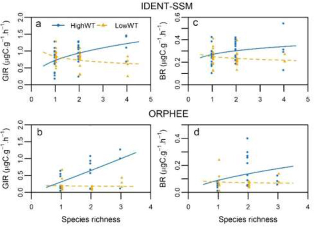

Figure 1. Relationships of soil microbial glucose-induced respiration (GIR) (a, b) and basal respiration (BR) (c, d) with species richness and water treatments (WT) at the IDENT-SSM and ORPHEE tree diversity experiments.

The NME of GIR, and BR were more strongly influenced by water treatment than mixture composition (Fig. 2, Table S1). High water treatment had a significant, non-additive, positive effect on NME-GIR at both sites, and NME-BR at ORPHEE, while effect of low water treatment significantly differed from the high water treatment and was generally additive (NME=0; Figs. 2a, 2b, 2d). No effect of water treatment was observed on NME-BR at IDENT-SSM (Figs. 2c). The NME of GIR and BR for both sites did not differ with species richness (Fig. 2).

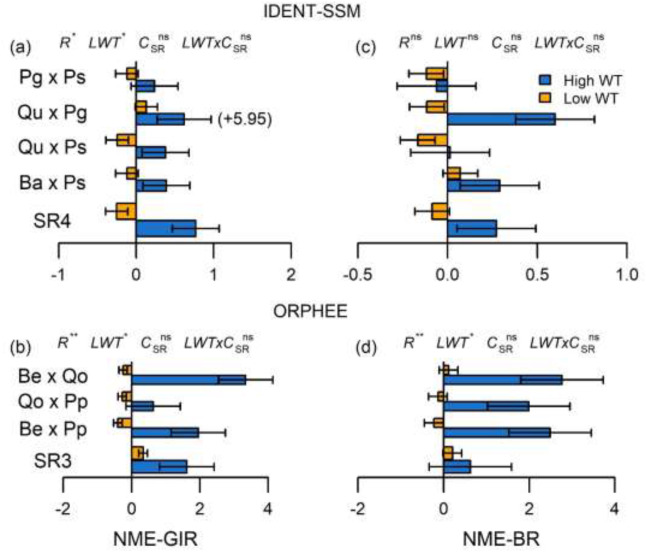

Figure 2. Net mixture effect (mean ± standard error) of soil microbial glucose-induced respiration (NME-GIR) (a, b) and basal respiration (NME-BR) (c, d) as a function of species mixture and water treatment (WT), at the IDENT-SSM and ORPHEE tree diversity experiments. Notes: See Table 1 for species and mixtures abbreviations. *p*-values (** 0.001<*p*<0.01; * 0.01<*p*<0.05; ns *p*>0.05) of the estimates for the high WT (set as reference WT, *R*), the low compared to high WT (*LWT*), the contrast between species mixtures of different species richness (*C*<sub>*SR*</sub>), and the interaction of *LWT* with *C*<sub>*SR*</sub> are indicated. Value of an outlier removed from analyses is enclosed by parentheses to the right of a bar.

### 3.2. Effects of tree species richness and water availability treatment on soil C, microbial H’, and microbial respiration of carboxylic and aromatic acids

Topsoil C was not influenced by tree species richness nor by water treatment at both sites (Table 3, Figs. 3a-b). Microbial H’ significantly increased with tree species richness in the high water treatment at IDENT-SSM, while it did not increase in the low water treatment (Table 3, Fig. 3c). Microbial H’ at ORPHEE did not significantly differ with tree species richness nor with water treatment (Table 3, Figs. 3d).

Table 3. Soil carbon (C), microbial H’ and microbial respiration of carboxylic and aromatic acids as a function of species richness and water treatments (WT) at the IDENT-SSM and ORPHEE tree diversity experiments.

| Fixed factors | Soil C | Microbial H’ | Microbial respiration of carboxylic acids | Microbial respiration of aromatic acids |
| --- | --- | --- | --- | --- |
| IDENT-SSM |  |  |  |  |
| Reference (High WT) | 19.62 (1.53) *** | 2.442 (0.020) *** | 0.273 (0.019) *** | 0.170 (0.011) *** |
| Species richness | 0.10 (0.28) | 0.018 (0.008) * | -0.016 (0.007) * | -0.001 (0.005) |
| Low WT | -1.87 (2.17) | 0.047 (0.028) | -0.045 (0.027) | -0.042 (0.015) * |
| Low WT x Species richness | -0.16 (0.40) | -0.032 (0.012) ** | 0.018 (0.010) | 0.015 (0.008) |
| **ORPHEE** |  |  |  |  |
| Reference (High WT) | 23.09 (5.10) *** | 2.270 (0.092) *** | 0.053 (0.045) | 0.185 (0.070) * |
| Species richness | 2.93 (2.68) | 0.036 (0.052) | 0.059 (0.024) * | -0.003 (0.038) |
| Low WT | 0.24 (7.21) | -0.045 (0.126) | 0.098 (0.063) | -0.081 (0.099) |
| Low WT x Species richness | -2.98 (3.78) | -0.043 (0.070) | -0.066 (0.034) | 0.031 (0.053) |

Notes: Microbial H’ (functional diversity, based on Shannon-Weaver diversity index), and microbial respiration of carboxylic and aromatic acids (functional identity, based on proportions of total substrates IR) were assessed with the respective respirations induced by 14 substrates (μgC.g<sup>-1</sup>.h<sup>-1</sup>). The high WT was set as reference WT in linear mixed models. Parameter estimates, standard errors (in parentheses) and *p*-values (*** *p*<0.001; ** 0.001<*p*<0.01; * 0.01<*p*<0.05) are indicated.

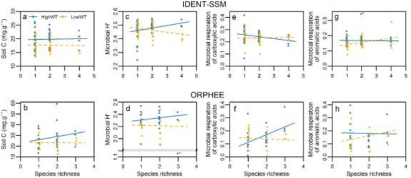

Figure 3. Soil carbon (C) (a, b), microbial H’ (c, d) and microbial respiration of carboxylic and aromatic acids (e-h), as a function of species richness and water treatments (WT) at the IDENT-SSM and ORPHEE tree diversity experiments. Notes: Microbial H’ (functional diversity, based on Shannon-Weaver diversity index), and microbial respiration of carboxylic and aromatic acids (functional identity, based on proportions of total substrates respiration) were assessed with respirations induced by 14 substrates (μgC.g<sup>-1</sup>.h<sup>-1</sup>). We used (*) to represent outlier, and horizontal lines to represent a gap on y-axis from 1.2 to 1.75 for microbial H’ at ORPHEE (d).

Microbial respiration of carboxylic acids significantly decreased with tree species richness in the high water treatment at IDENT-SSM, whereas it increased in the high water treatment at ORPHEE (Table 3, Figs. 3e-f). Changes in microbial respiration of carboxylic acids with tree species richness did not significantly differ between the high and low water treatment at both sites (Table 3). Microbial respiration of aromatic acids was lower in the low compared to the high water treatment at IDENT-SSM, but was not affected by water treatment at ORPHEE, nor by tree species richness at both sites (Table 3, Figs. 3g-h).

### 3.3. Mechanisms by which tree species richness and water availability treatment affected soil microbial processes and soil C

Model selections with AICc followed by calculation of model-averaged estimates identified the suite of explanatory variables that most strongly influenced soil microbial GIR and BR at the two experimental sites (Table 4). At IDENT-SSM, microbial GIR significantly increased only with microbial H’, while microbial BR significantly increased with microbial GIR, moisture and microbial respiration of aromatic acids. At ORPHEE, microbial GIR significantly increased with moisture and microbial H’, and decreased with temperature, while microbial BR significantly increased with microbial GIR and decreased with microbial H’.

Table 4. Model-averaged estimates (*E*), unconditional standard errors (*SE*) and 95% confidence interval (*CI*) of variables potentially influencing soil microbial glucose-induced respiration (GIR) and basal respiration (BR) at the IDENT-SSM and ORPHEE tree diversity experiments.

| IDENT-SSM | Microbial GIR |  | Microbial BR |  |
| --- | --- | --- | --- | --- |
| Explanatory variables | *E* (*SE*) | 95% *CI* | *E* (*SE*) | 95% *CI* |
| Microbial GIR |  |  | **0.15 (0.03)** | **[0.08; 0.21]** |
| Temperature | *-0.01 (0.12)* | *[-0.24; 0.22]* | *-0.05 (0.03)* | *[-0.11; 0.01]* |
| Moisture | 2.98 (1.91) | [-0.75; 6.72] | **1.23 (0.45)** | **[0.36; 2.11]** |
| C: N | 0.097 (0.050) | [-0.001; 0.195] | 0.01 (0.01) | [-0.02; 0.03] |
| pH | 0.12 (0.14) | [-0.16; 0.39] | 0.05 (0.03) | [-0.02; 0.12] |
| Tree biomass | 0.00 (0.01) | [-0.01; 0.02] | -0.001 (0.002) | [-0.005; 0.002] |
| Soil C | 0.029 (0.017) | [-0.005; 0.063] | 0.007 (0.004) | [-0.0002; 0.014] |
| Microbial H’ | **2.37 (0.55)** | **[1.30; 3.45]** | 0.25 (0.17) | [-0.08; 0.57] |
| Microbial respiration of aromatic acids | -1.40 (1.04) | [-3.43; 0.63] | **0.94 (0.26)** | **[0.43; 1.44]** |
| **ORPHEE** | **Microbial GIR***<sup>a</sup>* |  | **Microbial BR***<sup>a</sup>* |  |
| **Explanatory variables** | *E* (*SE*) | **95% *CI*** | *E* (*SE*) | **95% *CI*** |
| Microbial GIR*<sup>a</sup>* |  |  | **0.35 (0.04)** | **[0.27; 0.43]** |
| Temperature | **-0.08 (0.03)** | **[-0.14; -0.02]** | 0.01 (0.01) | [-0.02; 0.04] |
| Moisture | **3.53 (0.99)** | **[1.59; 5.47]** | -0.02 (0.34) | [-0.69; 0.64] |
| C: N | 0.002 (0.003) | [-0.004; 0.008] | -0.001 (0.001) | [-0.003; 0.001] |
| pH | -0.09 (0.13) | [-0.34; 0.15] | 0.00 (0.05) | [-0.11; 0.11] |
| Tree biomass | 0.0001 (0.0001) | [-0.00001; 0.0003] | 0.00001 (0.00004) | [-0.00006; 0.00008] |
| Soil C | 0.009 (0.005) | [-0.0005; 0.0177] | 0.001 (0.001) | [-0.002; 0.004] |
| H’ | **0.36 (0.17)** | **[0.04; 0.69]** | **-0.13 (0.05)** | **[-0.23; -0.04]** |
| Microbial respiration of carboxylic acids | 0.60 (0.36) | [-0.12; 1.31] | -0.06 (0.14) | [-0.32; 0.21] |

Notes: Significant relationships (when 95% *CI* do not include 0) are indicated in bold font. Results of temperature in IDENT-SSM are in italics because it was measured in only three of the nine mixtures. Microbial functional diversity was defined by H’, based on Shannon-Weaver diversity index. Microbial functional identity was defined by the variable with the highest effect on microbial GIR and BR that was microbial respiration of aromatic acids at IDENT-SSM and microbial respiration of carboxylic acids at ORPHEE.

**a**

A square root transformation was applied.

In the final path analysis model for IDENT-SSM, the significant interaction between tree species richness and water treatment on microbial H’ indicated that effect of tree species richness on microbial H’ was positive in the high water treatment (arrow in blue), but differed in the low water treatment and was not significant. Then tree species richness positively influenced microbial GIR and BR through a positive effect on microbial H’ in the high but not the low water treatment (Fig. 4a). The low water treatment significantly decreased soil moisture that in turn had a positive effect on microbial BR and a negative effect on microbial H’. Significant interaction between conifer proportion and water treatment on moisture indicated that conifer proportion influenced microbial BR and H’ through its positive effect on soil moisture in the low water treatment (arrow in orange), but not in the high water treatment. Microbial respiration of aromatic acids, which was lower in the low water treatment, positively influenced microbial BR. Although tree species richness effect on microbial respiration of aromatic acids was not significant in the high water treatment, it became significant in the low water treatment (arrow in orange).

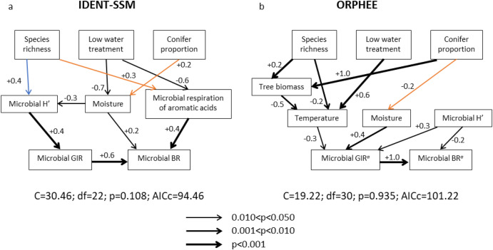

Figure 4. Path analysis models that quantify direct and indirect causal relationships of species richness, water treatment and conifer proportion with microbial glucose-induced respiration (GIR) and basal respiration (BR) at the IDENT-SSM (a) and ORPHEE (b) tree diversity experiments. These relationships are mediated by microbial H’, microbial respiration of aromatic acids, soil moisture, air temperature, and tree biomass. Notes: Fisher’s C statistic (C), degree of freedom (df), p-value (p) and value of the second-order Akaike’s Information Criterion (AICc) for each path analysis are provided. Line thickness indicates p-values of significant (*p*<0.05) relationships between two variables. Non-significant relationships that were tested were removed for clarity. When a significant interactive effect of water treatment occurred, the value of coefficients for both the high water treatment (blue) and the low water treatment (orange) are presented. Microbial GIR, BR, H’ and respiration of aromatic acids were used to estimate microbial biomass, activity, functional diversity and functional identity, respectively (see notes of Tables 3 and 4).<sup>*a*</sup> A square root transformation was applied.

The final path analysis model for the ORPHEE site indicated that species richness positively influenced microbial GIR and BR through direct and indirect, negative effects on temperature, which was higher in the low than the high water treatment (Fig. 4b). Conifer proportion influenced microbial GIR positively through its effect on tree biomass and negatively in the low water treatment (arrow in orange) through its effect on soil moisture. Tree biomass, which was positively influenced by both species richness and conifer proportion, influenced microbial GIR through temperature effects. Although microbial H’ did have a positive influence on microbial GIR, and a negative effect on microbial BR, microbial H’ was independent of tree species richness, water treatment and conifer proportion.

## 4. Discussion

### 4.1. Tree species richness effect hypothesis

As predicted by our first hypothesis, an increase in microbial biomass (as estimated by GIR) with tree species richness was observed in the high water availability treatment at both sites. To a lesser extent, microbial activity (as estimated by BR) that was influenced by microbial biomass also increased with tree species richness. Such increases have been found previously for grasslands (Zak et al., 2003; Eisenhauer et al., 2010) and tree communities (Thoms et al., 2010; Khlifa et al., 2017). Despite distinctly different patterns at the IDENT-SSM and ORPHEE sites (Figure 1), the effect of tree species richness on microbial biomass and activity at both sites resulted largely from mixing of species (i.e., mixtures compared to monocultures), but relatively little by the number of species in a mixture (Figure 2). Functional redundancy at the tree or microbial level (Rosenfeld, 2002; Delgado-Baquerizo et al., 2016) is often put forth as an explanation for reduced diversity effects on microbial biomass and activity at higher levels of tree species richness (Khlifa et al., 2017). Alternatively, it is possible that all tree species contribute to microbial ecosystem functioning as predicted by the singular hypothesis (Eisenhauer et al., 2010), but with distinct and overlapping effect among tree species. Another possible explanation for this result is that species identity of tree communities is more important to microbial biomass and activity responses than species diversity (Scheibe et al., 2015), as it has been shown for understorey vegetation at ORPHEE (Corcket et al., 2020).

Our hypothesis that microbial functional diversity (as estimated by H’) will increase with tree species richness was supported only in the high water treatment at the IDENT-SSM site. Increased soil microbial functional diversity with tree species richness may be due to increased microbial species diversity, that would result from the higher diversity of either litter and root exudates, soil abiotic conditions or microhabitats occurring with higher tree species richness (Hooper et al., 2000; Stephan et al., 2000; Hättenschwiler et al., 2005). This so-called “chain of diversities” was found in previous studies of plant species richness effects on the diversity of soil microbial species (Liu et al., 2020) and soil microbial functions (Stephan et al., 2000; Shihan et al., 2017). However, our first hypothesis regarding tree species richness effect on microbial biomass, activity and functional diversity was not verified in the low water treatment (see interactions effect hypothesis).

Contrary to our initial expectations, microbial functional diversity was independent of tree species richness in both water treatments at ORPHEE, whereas microbial functional identity (as estimated by respiration of carboxylic acids and respiration of aromatic acids) was influenced by tree species richness, which means it was not a simple addition of microbial functional identity of monocultures. Indeed, mixtures of tree species may modify bottom-up effects of trees on microbial communities by mechanisms that affect litter quantity and quality (e.g. competitive exclusion among tree species, Jiang et al., 2009; or foliar and root herbivory, Bardgett and Wardle, 2003), competition among microorganisms (Boddy, 2000), or top-down factors (e.g. predation, De Ruiter et al., 1995). Consequently, composition of microbial communities and their ability to catabolize specific organic compounds may be altered, such as our results obtained in the high water treatment at both sites. Carboxylic acids that we assessed are produced by most living organisms, including plants, animals, fungi and bacteria, play key roles in their metabolism, and can be degraded by different species of bacteria possibly in association with fungi (Palmieri et al., 2019). Knowing which of the aforementioned mechanisms explains our results in each site needs further investigation.

Contrary to our first hypothesis, we did not find any significant tree species richness effects on soil C in the topsoil, similarly to the studies of Laganière et al. (2015) and Guckland et al. (2009) in mature forests. As proposed for microbial biomass and activity, tree species identity effects on SOC was of comparatively greater importance than tree species richness and may mask tree species richness effects (Dawud et al., 2016). Moreover, the two plantations studied here may simply have been too young for tree species richness effects to develop. Indeed, previous studies have reported significant time lags before change in soil C with plant diversity in grasslands (Lange et al., 2015) or with afforestation (Mayer et al. 2020) was detected.

### 4.2. Water availability hypothesis

Our second hypothesis was partly supported as water-limited conditions in mixtures decreased microbial biomass at both sites and microbial activity at ORPHEE. Different mechanisms may be implied in accordance with our results. First, the lower soil moisture that directly resulted from reduction in precipitation at IDENT-SSM may have produced discontinuity of water in soil pores and slower diffusion of solutes and enzymes, which may have limited the supply of organic compounds available to microorganisms (Manzoni et al. 2012). Also, the lower soil moisture may have induced, depending on specific physiological capacity of microbial communities, adaptive dormancy to improve survival under drought, or preferential allocation of resources to non-structural compounds that improve drought tolerance (Schimel et al. 2007; Moyano et al 2013).

Another mechanism by which chronic water shortage may have impacted microbial biomass and activity is the modification of productivity, allocation and architecture balance among tree species, which could influence microorganisms through its effect on soil C inputs, soil moisture and temperature (Renaud et al., 2011; Zhou et al., 2016). Indeed, we obtained a significant water treatment effect on temperature at ORPHEE likely mediated by tree canopy cover, as well as a conifer proportion effect on soil moisture in the low water treatment at both sites. However, a longer time is required for water treatment effect on trees to affect soil C. But the high correlation found between soil C and moisture at both sites (Table S3) indicates that soil moisture may have already influenced soil C, and reciprocally, soil C may have influenced moisture through its impact on water holding capacity (Moyano et al., 2013; Rawls et al., 2003).

Finally, water limitations may have resulted in compositional shift in microbial communities towards greater abundance of slower-growing drought-tolerant species (Schimel et al., 2007). The change in microbial functional identity with water treatment we obtained at IDENT-SSM is in accordance with this shift in microbial composition. But contrary to hypothesis two, microbial respiration of carboxylic acids did not vary with water treatment and that of aromatic acids was lower in the low water treatment, which was likely caused by a participation of bacteria in the degradation of aromatic compounds higher than expected (Bugg et al., 2011). This question would be solved by determining microbial species composition.

Beyond these possible mechanisms, the fact that effects of water treatment on soil microbial processes depended on tree species richness indicated these two factors may thus have indirectly influenced the microbial biomass and activity through similar tree or soil variables (see interactions effect and mechanisms hypotheses).

### 4.3. Interactions effect hypothesis

Abiotic factors have been shown to modulate the relationship of tree diversity with productivity in forest ecosystems (Paquette and Messier, 2011; Forrester, 2014). In contrast, the relationship of plant diversity with soil functions have generally been little influenced by abiotic factors including soil moisture availability (Vogel et al., 2013; Thakur et al., 2015; Shihan et al., 2017). In our study, we found significant interactions between species richness and water treatment on soil microbial biomass, activity, and functional diversity. However, our results do not support our third hypothesis that tree diversity effects on microbial processes will be comparatively larger in the low than the high water treatment, as predicted by the stress-gradient hypothesis. Although this hypothesis is broadly supported by experiments examining productivity responses of diverse plant communities (He et al., 2013), contradictory responses are not uncommon (Maestre et al., 2009), particularly in natural and managed forests (Forrester, 2014; Jactel et al., 2018; Belluau et al., 2020).

Hypothesis three was based on the fact that complementarity interactions among tree species would relatively increase with tree species richness and with environmental stress, which would “improve” soil functions. But in the two sites studied here, improvement (increases) in microbial biomass and activity with tree species richness only occurred in plots of high water availability. The higher understorey vegetation height in the high water treatment at ORPHEE (Corcket et al., 2020) is consistent with an improvement of trophic resources for microbes and with the widening of their ecological niches. However, improvement in microbial biomass and activity with tree species richness did not occur in plots where water stress was applied. At the IDENT-SSM site, the main factor that was identified to explain the increase in microbial biomass in the high water treatment was a “chain of diversities” from tree species richness to microbial functional diversity. This chain was interrupted in the low water treatment, probably because water stress affected, beside tree species, species of higher trophic levels, either herbivores, microorganisms or predators, and modified interactions among these species. At the ORPHEE site, the strong increase in temperature in the low water treatment, amplified by conditions of water stress, may have created a harsh microclimate limiting interactions among species and effects of tree species richness on microbial biomass and activity. More generally, it is also possible that microorganisms used physiological processes such as dormancy (Schimel et al. 2007; Moyano et al 2013) to resist to conditions of water stress, stopped their activity to survive, and then did not benefit from tree species richness. How tree species richness and drought interact to impact ecosystem functions depends on tree species characteristics, and nature and intensity of the stress gradient (Jactel et al., 2017; Grossiord, 2019). Further study is necessary to refine the stress-gradient hypothesis for soil functions.

### 4.4. Mechanisms hypothesis

Confirming our fourth hypothesis, the main variables by which tree species richness influenced microbial biomass and activity were, in interaction with water availability conditions (see above), microbial functional diversity and identity at IDENT-SSM, and air temperature at ORPHEE.

The increase in microbial functional diversity with tree species richness (“chain of diversities”) in the high water treatment at IDENT-SSM was a major driver of higher soil microbial biomass and activity as found by Shihan et al. (2017). This relationship can be explained by niche partitioning processes through higher dissimilarity in litter substrates fostering a greater spectrum of resources available for microbial use (Shihan et al., 2017), and by facilitative processes among microbial species (Tiunov and Scheu, 2005). Moreover, tree species richness also influenced microbial activity at IDENT-SSM through their effect on microbial ability to catabolize aromatic acids. This is consistent with the fact that complex structural compounds such as lignin-derived aromatic substrates are catabolized with lower microbial efficiency (i.e., higher respiration) than simple metabolic compounds (Cotrufo et al., 2013).

The role of microclimate in expression of tree species richness effects on soil microbial processes, as we found at ORPHEE, has been reported previously (Eisenhauer et al., 2010; Seidelmann et al., 2016), but mechanisms by which tree diversity influences microclimate are still unclear compared to tree species identity effects (Augusto et al., 2015). The modification of productivity, allocation and architecture balance among tree species would be a major factor explaining effect of tree species richness on microclimate (Renaud et al., 2011; Grossiord et al., 2014). In our results, tree biomass partly explains tree species richness effect on temperature, but not completely, as a direct link between them remains in the path analysis. Other measures than tree biomass, such as tree canopy architecture or leaf area, would be more relevant. Another factor influencing soil microorganisms at ORPHEE was microbial H’ which produced opposite effect on microbial activity and biomass, consistently with the study of Domeignoz-Horta et al. (2020), which found a positive influence of microbial H’ on microbial efficiency (i.e., the fraction of C retained in biomass compared to the fraction respired).

The models described in our path analyses are admittedly incomplete. Other potential influential factors such as root litter and exudates (Eisenhauer et al., 2010), nutrients (Thoms et al., 2010), litter quantity and quality (Cotrufo et al., 2013) and species composition of microbial communities (Jiang et al., 2012) would add a deeper understanding of the mechanisms by which tree communities and environmental variables affect microbial processes. Considering the role of microclimate for microbial processes, a more thorough assessment of temperature and moisture variations

would be also necessary for this understanding. Moreover, conifer proportion, despite its impact on litter quality (Augusto et al., 2015), did not directly influence microbial processes, indicating that tree species identity is more complex than a simple distinction between conifer and broadleaf species.

The dynamics by which tree species create bottom-up effects on soil functions have different lag times, so that sampling at IDENT-SSM after 4.2 years and at ORPHEE after 9.0 years can partly explain the different mechanisms observed between the two sites. Following the initial setting of a mixed-species plantation, modifications in the quantity and quality of aboveground and belowground litters would change composition and activity of soil biota, which would explain why we observed tree species richness effect on microbial communities at both sites. Over time, feedbacks between soil microbial and plant communities will further increase tree diversity effects on tree productivity, such as what occurs at ORPHEE. With a longer study, we contend that diversity effects on soil carbon dynamics would develop. But differences between the two sites may also result from their different soil fertility, climate and species characteristics, and from the different experimental design used such as plot sizes, understorey management or temperature measurements (but generally air and soil temperatures are correlated; Brown et al., 2000). Repeating sampling on the same experimental site at different stages of tree development would confirm the dynamics by which tree species richness impacts the whole ecosystem.

## 5. Conclusions

Our study carried out in young mixed species plantations demonstrated how water stress conditions and tree species richness interact to affect microbial processes through influencing similar variables that were microbial functional diversity after 4.2 years and temperature after 9.0 years. Soil microbial processes rapidly respond to tree species richness and water availability treatment, compared to other components of the ecosystem. A better understanding of the dynamics by which tree species diversity influences the soil, microclimate and the whole ecosystem is necessary and require time series experiments in plantations at different stages of maturity. Biodiversity-ecosystem functions relationships are largely based on aboveground productivity responses of grassland ecosystems exposed to single set of climatic and edaphic conditions. Clearly, further study of diversity effects in plantations and natural forest ecosystems on multiple trophic levels exposed to a range of environmental conditions are needed to further test and refine these relationships.

Tree species identity was more important to soil microbial processes than tree species diversity in our study, but was not represented by conifer proportion. This suggests that, in addition to knowledge of functional diversity, knowledge of identity effects of tree communities is needed for a better mechanistic understanding of tree species composition effects on soil processes (Mayer et al, 2020), and for establishing relationships among litter quality, microbial species composition, microbial functions and the role of other soil biota.

## Uncited reference

Achat et al., 2009, Annighö fer et al., 2016, Archambault et al., 2019, Castagneyrol et al., 2018, Dai, 2011, IUSS Working Group WRB, 2014, R Development Core Team, 2019, Shvidenko et al., 2005, Soil Classification Working Group, 1998, Verheyen et al., 2016.

## Declaration of Competing Interest

The authors declare that they have no known competing financial interests or personal relationships that could have appeared to influence the work reported in this paper.

## 6. Acknowledgements

We are grateful to Nathalie Fromin, Bruno Buatois, Alain Brousseau, Marie R. Coyea, Jean-Guy Catford, Sébastien Dumont, Jessica Gosselin for laboratory analyses and assistance, Brian Brown, Florine Routier, Edith Reuzeau for field assistance, and Celine Meredieu for providing data on trees at ORPHEE. This study was supported by a postdoctoral research scholarship from the Fonds québécois de recherche sur la nature et les technologies (FRQNT) and support from an NSERC Discovery Grant to ADM. The activities of LA and HJ, dendrometric measurements and irrigation at the ORPHEE site were supported by the French National Research Agency in the framework of the DiPTiCC research project (ANR-16-CE32-0003).

## Appendix A. Supplementary data

The following is the Supplementary data to this article:[Download : Download Word document (6MB)](https://ars.els-cdn.com/content/image/1-s2.0-S0038071721000523-mmc1.docx)

## 7. References

**Achat et al., 2009**

D.L. Achat, M.R. Bakker, L. Augusto, É. Saur, L. Dousseron, C. Morel

**Evaluation of the phosphorus status of P-deficient podzols in temperate pine stands: combining isotopic dilution and extraction methods**

Biogeochemistry, 92 (2009), pp. 183-200, 10.1007/s10533-008-9283-7

[CrossRef](https://doi.org/10.1007/s10533-008-9283-7)[View Record in Scopus](https://www.scopus.com/inward/record.url?eid=2-s2.0-61349193108&partnerID=10&rel=R3.0.0)Google Scholar

**Anderson and Domsch, 1978**

J.P.E. Anderson, K.H. Domsch

**A physiological method for the quantitative measurement of microbial biomass in soils**

Soil Biology and Biochemistry, 10 (1978), pp. 215-221, 10.1016/0038-0717(78)90099-8

[Article](https://www.sciencedirect.com/science/article/pii/0038071778900998)[Download PDF](https://www.sciencedirect.com/science/article/pii/0038071778900998/pdf?md5=3c57a9ba985d40ee2a626cb8f712a452&pid=1-s2.0-0038071778900998-main.pdf)[View Record in Scopus](https://www.scopus.com/inward/record.url?eid=2-s2.0-34247275586&partnerID=10&rel=R3.0.0)Google Scholar

**Annighöfer et al., 2016**

P. Annighöfer, A. Ameztegui, C. Ammer, P. Balandier, N. Bartsch, A. Bolte, L. Coll, C. Collet, J. Ewald, N. Frischbier, T. Gebereyesus, J. Haase, T. Hamm, B. Hirschfelder, F. Huth, G. Kändler, A. Kahl, H. Kawaletz, C. Kuehne, A. Lacointe, N. Lin, M. Löf, P. Malagoli, A. Marquier, S. Müller, S. Promberger, D. Provendier, H. Röhle, J. Sathornkich, P. Schall, M. Scherer-Lorenzen, J. Schröder, C. Seele, J. Weidig, C. Wirth, H. Wolf, J. Wollmerstädt, M. Mund

**Species-specific and generic biomass equations for seedlings and saplings of European tree species**

European Journal of Forest Research, 135 (2016), pp. 313-329, 10.1007/s10342-016-0937-z

[CrossRef](https://doi.org/10.1007/s10342-016-0937-z)[View Record in Scopus](https://www.scopus.com/inward/record.url?eid=2-s2.0-84954493724&partnerID=10&rel=R3.0.0)Google Scholar

**Archambault et al., 2019**

C. Archambault, A. Paquette, C. Messier, R. Khlifa, A.D. Munson, I.T. Handa

**Evergreenness influences fine root growth more than tree diversity in a common garden experiment**

Oecologia, 189 (2019), pp. 1027-1039, 10.1007/s00442-019-04373-5

[CrossRef](https://doi.org/10.1007/s00442-019-04373-5)Google Scholar

**Augusto et al., 2015**

L. Augusto, A. De Schrijver, L. Vesterdal, A. Smolander, C. Prescott, J. Ranger

**Influences of evergreen gymnosperm and deciduous angiosperm tree species on the functioning of temperate and boreal forests**

Biological Reviews, 90 (2015), pp. 444-466, 10.1111/brv.12119

[CrossRef](https://doi.org/10.1111/brv.12119)[View Record in Scopus](https://www.scopus.com/inward/record.url?eid=2-s2.0-84927121762&partnerID=10&rel=R3.0.0)Google Scholar

**Baize and Girard, 2009**

Baize, D., Girard, M.C., 2009. Référentiel pédologique-Association française pour l’étude du sol (AFES). Éditions Quae, Versailles.

Google Scholar

**Bardgett and Wardle, 2003**

R.D. Bardgett, D.A. Wardle

**Herbivore-mediated linkages between aboveground and belowground communities**

Ecology, 84 (2003), pp. 2258-2268, 10.1890/02-0274

[CrossRef](https://doi.org/10.1890/02-0274)[View Record in Scopus](https://www.scopus.com/inward/record.url?eid=2-s2.0-0242308319&partnerID=10&rel=R3.0.0)[Google Scholar](https://scholar.google.com/scholar_lookup?title=Herbivore-mediated%20linkages%20between%20aboveground%20and%20belowground%20communities&publication_year=2003&author=R.D.%20Bardgett&author=D.A.%20Wardle)

**Bastida et al., 2017**

F. Bastida, I.F. Torres, M. Andrés-Abellán, P. Baldrian, R. López-Mondéjar, T. Větrovský, H.H. Richnow, R. Starke, S. Ondoño, C. García, F.R. López-Serrano, N. Jehmlich

**Differential sensitivity of total and active soil microbial communities to drought and forest management**

Global Change Biology, 23 (2017), pp. 4185-4203, 10.1111/gcb.13790

[CrossRef](https://doi.org/10.1111/gcb.13790)[View Record in Scopus](https://www.scopus.com/inward/record.url?eid=2-s2.0-85021807507&partnerID=10&rel=R3.0.0)Google Scholar

**Bauhus et al., 2017**

Bauhus, J., Forrester, D.I., Gardiner, B., Jactel, H., Vallejo, R., Pretzsch, H., 2017. Ecological stability of mixed-species forests. In: Pretzsch, H., Forrester, D.I., Bauhus, J. (Eds.), Mixed-Species Forests, Ecology and Management. Springer, Berlin, pp. 337–382. doi: 10.1007/978-3-662-54553-9_7

Google Scholar

**Belluau et al., 2020**

M. Belluau, V. Vitali, W.C. Parker, A. Paquette, C. Messier

**Overyielding in young tree communities does not support the stress-gradient hypothesis and is favoured by functional diversity and higher water availability**

Journal of Ecology (2020)

(in review)

Google Scholar

**Boddy, 2000**

L. Boddy

**Interspecific combative interactions between wood-decaying basidiomycetes**

FEMS Microbiology Ecology, 31 (2000), pp. 185-194, 10.1111/j.1574-6941.2000.tb00683.x

[Article](https://www.sciencedirect.com/science/article/pii/S0168649699000938)[Download PDF](https://www.sciencedirect.com/science/article/pii/S0168649699000938/pdfft?md5=ebf4ffe761ff02206e51ec9b3469d8f9&pid=1-s2.0-S0168649699000938-main.pdf)[View Record in Scopus](https://www.scopus.com/inward/record.url?eid=2-s2.0-0034105932&partnerID=10&rel=R3.0.0)[Google Scholar](https://scholar.google.com/scholar_lookup?title=Interspecific%20combative%20interactions%20between%20wood-decaying%20basidiomycetes&publication_year=2000&author=L.%20Boddy)

**Brown et al., 2000**

S.E. Brown, K.S. Pregitzer, D.D. Reed, A.J. Burton

**Predicting daily mean soil temperature from daily mean air temperature in four northern hardwood forest stands**

Forest Science, 46 (2000), pp. 297-301, 10.1093/FORESTSCIENCE/46.2.297

[View Record in Scopus](https://www.scopus.com/inward/record.url?eid=2-s2.0-0034038290&partnerID=10&rel=R3.0.0)Google Scholar

**Bugg et al., 2011**

T.D.H. Bugg, M. Ahmad, E.M. Hardiman, R. Rahmanpour

**Pathways for degradation of lignin in bacteria and fungi**

Natural Products Reports, 28 (2011), pp. 1883-1896, 10.1039/c1np00042j

[CrossRef](https://doi.org/10.1039/c1np00042j)[View Record in Scopus](https://www.scopus.com/inward/record.url?eid=2-s2.0-81355123362&partnerID=10&rel=R3.0.0)Google Scholar

**Burnham and Anderson, 2002**

Burnham, K.P., Anderson, D.R., 2002. Model selection and multimodel inference, A practical information-theoretic approach, second ed. Springer, New York.

Google Scholar

**Campbell et al., 2003**

C.D. Campbell, S.J. Chapman, C.M. Cameron, M.S. Davidson, J.M. Potts

**A rapid microtiter plate method to measure carbon dioxide evolved from carbon substrate amendments so as to determine the physiological profiles of soil microbial communities by using whole soil**

Applied and Environmental Microbiology, 69 (2003), p. 3593, 10.1128/AEM.69.6.3593-3599.2003

LP – 3599

[View Record in Scopus](https://www.scopus.com/inward/record.url?eid=2-s2.0-0038315527&partnerID=10&rel=R3.0.0)Google Scholar

**Campbell et al., 1997**

C.D. Campbell, S.J. Grayston, D.J. Hirst

**Use of rhizosphere carbon sources in sole carbon source tests to discriminate soil microbial communities**

Journal of Microbiological Methods, 30 (1997), pp. 33-41, 10.1016/S0167-7012(97)00041-9

[Article](https://www.sciencedirect.com/science/article/pii/S0167701297000419)[Download PDF](https://www.sciencedirect.com/science/article/pii/S0167701297000419/pdfft?md5=b8a72c14ac057170217df326f29aafe9&pid=1-s2.0-S0167701297000419-main.pdf)[View Record in Scopus](https://www.scopus.com/inward/record.url?eid=2-s2.0-0030930388&partnerID=10&rel=R3.0.0)Google Scholar

**Castagneyrol et al., 2018**

B. Castagneyrol, H. Jactel, X. Moreira

**Anti-herbivore defences and insect herbivory: Interactive effects of drought and tree neighbours**

Journal of Ecology, 106 (2018), pp. 2043-2057, 10.1111/1365-2745.12956

[CrossRef](https://doi.org/10.1111/1365-2745.12956)[View Record in Scopus](https://www.scopus.com/inward/record.url?eid=2-s2.0-85043712088&partnerID=10&rel=R3.0.0)Google Scholar

**Corcket et al., 2020**

E. Corcket, D. Alard, I. Van Halder, H. Jactel, B. Garrido Diaz, E. Reuzeau, B. Castagneyrol

**Canopy composition and drought shape understorey plant assemblages in a young tree diversity experiment**

Journal of Vegetation Science, 31 (2020), pp. 803-816, 10.1111/jvs.12903

[CrossRef](https://doi.org/10.1111/jvs.12903)[View Record in Scopus](https://www.scopus.com/inward/record.url?eid=2-s2.0-85089097079&partnerID=10&rel=R3.0.0)Google Scholar

**Cotrufo et al., 2013**

M.F. Cotrufo, M.D. Wallenstein, C.M. Boot, K. Denef, E. Paul

**The Microbial Efficiency-Matrix Stabilization (MEMS) framework integrates plant litter decomposition with soil organic matter stabilization: do labile plant inputs form stable soil organic matter?**

Global Change Biology, 19 (2013), pp. 988-995, 10.1111/gcb.12113

[CrossRef](https://doi.org/10.1111/gcb.12113)[View Record in Scopus](https://www.scopus.com/inward/record.url?eid=2-s2.0-84874752916&partnerID=10&rel=R3.0.0)Google Scholar

**Dai, 2011**

A. Dai

**Drought under global warming: a review**

WIREs Climate Change, 2 (2011), pp. 45-65, 10.1002/wcc.81

[CrossRef](https://doi.org/10.1002/wcc.81)[View Record in Scopus](https://www.scopus.com/inward/record.url?eid=2-s2.0-79951477455&partnerID=10&rel=R3.0.0)[Google Scholar](https://scholar.google.com/scholar_lookup?title=Drought%20under%20global%20warming%3A%20a%20review&publication_year=2011&author=A.%20Dai)

**Dawud et al., 2016**

S.M. Dawud, K. Raulund-Rasmussen, T. Domisch, L. Finér, B. Jaroszewicz, L. Vesterdal

**Is tree species diversity or species identity the more important driver of soil carbon stocks, C/N ratio, and pH?**

Ecosystems, 19 (2016), pp. 645-660, 10.1007/s10021-016-9958-1

[CrossRef](https://doi.org/10.1007/s10021-016-9958-1)[View Record in Scopus](https://www.scopus.com/inward/record.url?eid=2-s2.0-84970015989&partnerID=10&rel=R3.0.0)[Google Scholar](https://scholar.google.com/scholar?q=Is%20tree%20species%20diversity%20or%20species%20identity%20the%20more%20important%20driver%20of%20soil%20carbon%20stocks,%20CN%20ratio,%20and%20pH)

**De Boer et al., 2005**

W. De Boer, L.B. Folman, R.C. Summerbell, L. Boddy

**Living in a fungal world: impact of fungi on soil bacterial niche development**

FEMS Microbiology Reviews, 29 (2005), pp. 795-811, 10.1016/j.femsre.2004.11.005

[View Record in Scopus](https://www.scopus.com/inward/record.url?eid=2-s2.0-23744460935&partnerID=10&rel=R3.0.0)Google Scholar

**De Ruiter et al., 1995**

P.C. De Ruiter, A.-M. Neutel, J.C. Moore

**Energetics, patterns of interaction strengths, and stability in real ecosystems**

Science, 269 (1257) (1995), 10.1126/science.269.5228.1257

LP – 1260

Google Scholar

**De Vries and Shade, 2013**

F. De Vries, A. Shade

**Controls on soil microbial community stability under climate change**

Frontiers in Microbiology, 4 (2013), p. 265, 10.3389/fmicb.2013.00265

[Google Scholar](https://scholar.google.com/scholar_lookup?title=Controls%20on%20soil%20microbial%20community%20stability%20under%20climate%20change&publication_year=2013&author=F.%20De%20Vries&author=A.%20Shade)

**Delgado-Baquerizo et al., 2016**

M. Delgado-Baquerizo, L. Giaramida, P.B. Reich, A.N. Khachane, K. Hamonts, C. Edwards, L.A. Lawton, B.K. Singh

**Lack of functional redundancy in the relationship between microbial diversity and ecosystem functioning**

Journal of Ecology, 104 (2016), pp. 936-946, 10.1111/1365-2745.12585

[CrossRef](https://doi.org/10.1111/1365-2745.12585)[View Record in Scopus](https://www.scopus.com/inward/record.url?eid=2-s2.0-84966474565&partnerID=10&rel=R3.0.0)Google Scholar

**Domeignoz-Horta et al., 2020**

L.A. Domeignoz-Horta, G. Pold, X.-J.A. Liu, S.D. Frey, J.M. Melillo, K.M. DeAngelis

**Microbial diversity drives carbon use efficiency in a model soil**

Nature Communications, 11 (2020), p. 3684, 10.1038/s41467-020-17502-z

[View Record in Scopus](https://www.scopus.com/inward/record.url?eid=2-s2.0-85088390670&partnerID=10&rel=R3.0.0)Google Scholar

**Eisenhauer et al., 2010**

N. Eisenhauer, H. Beßler, C. Engels, G. Gleixner, M. Habekost, A. Milcu, S. Partsch, A.C.W. Sabais, C. Scherber, S. Steinbeiss, A. Weigelt, W.W. Weisser, S. Scheu

**Plant diversity effects on soil microorganisms support the singular hypothesis**

Ecology, 91 (2010), pp. 485-496, 10.1890/08-2338.1

[CrossRef](https://doi.org/10.1890/08-2338.1)[View Record in Scopus](https://www.scopus.com/inward/record.url?eid=2-s2.0-77949302399&partnerID=10&rel=R3.0.0)Google Scholar

**Fontaine et al., 2007**

S. Fontaine, S. Barot, P. Barré, N. Bdioui, B. Mary, C. Rumpel

**Stability of organic carbon in deep soil layers controlled by fresh carbon supply**

Nature, 450 (2007), pp. 277-280, 10.1038/nature06275

[CrossRef](https://doi.org/10.1038/nature06275)[View Record in Scopus](https://www.scopus.com/inward/record.url?eid=2-s2.0-36049040295&partnerID=10&rel=R3.0.0)Google Scholar

**Forrester, 2014**

D.I. Forrester

**The spatial and temporal dynamics of species interactions in mixed-species forests: From pattern to process**

Forest Ecology and Management, 312 (2014), pp. 282-292, 10.1016/j.foreco.2013.10.003

[Article](https://www.sciencedirect.com/science/article/pii/S0378112713006701)[Download PDF](https://www.sciencedirect.com/science/article/pii/S0378112713006701/pdfft?md5=9c1ae521a669db7ec6b4264f9e3fb169&pid=1-s2.0-S0378112713006701-main.pdf)[View Record in Scopus](https://www.scopus.com/inward/record.url?eid=2-s2.0-84888133348&partnerID=10&rel=R3.0.0)Google Scholar

**Grossiord, 2019**

C. Grossiord

**Having the right neighbors: how tree species diversity modulates drought impacts on forests**

New Phytologist n/a (2019), 10.1111/nph.15667

Google Scholar

**Grossiord et al., 2014**

C. Grossiord, A. Gessler, A. Granier, S. Berger, C. Bréchet, R. Hentschel, R. Hommel, M. Scherer-Lorenzen, D. Bonal

**Impact of interspecific interactions on the soil water uptake depth in a young temperate mixed species plantation**

Journal of Hydrology, 519 (2014), pp. 3511-3519, 10.1016/j.jhydrol.2014.11.011

[Article](https://www.sciencedirect.com/science/article/pii/S0022169414008968)[Download PDF](https://www.sciencedirect.com/science/article/pii/S0022169414008968/pdfft?md5=10a49ebfb1ca3e69b793f2fce879b2ea&pid=1-s2.0-S0022169414008968-main.pdf)[View Record in Scopus](https://www.scopus.com/inward/record.url?eid=2-s2.0-84919884442&partnerID=10&rel=R3.0.0)Google Scholar

**Grossman et al., 2018**

J.J. Grossman, M. Vanhellemont, N. Barsoum, J. Bauhus, H. Bruelheide, B. Castagneyrol, J. Cavender-Bares, N. Eisenhauer, O. Ferlian, D. Gravel, A. Hector, H. Jactel, H. Kreft, S. Mereu, C. Messier, B. Muys, C. Nock, A. Paquette, J. Parker, M.P. Perring, Q. Ponette, P.B. Reich, A. Schuldt, M. Staab, M. Weih, D.C. Zemp, M. Scherer-Lorenzen, K. Verheyen

**Synthesis and future research directions linking tree diversity to growth, survival, and damage in a global network of tree diversity experiments**

Environmental and Experimental Botany, 152 (2018), pp. 68-89, 10.1016/j.envexpbot.2017.12.015

[Article](https://www.sciencedirect.com/science/article/pii/S0098847217303428)[Download PDF](https://www.sciencedirect.com/science/article/pii/S0098847217303428/pdfft?md5=2bd347b8aa39968d6ef45a0e80166e76&pid=1-s2.0-S0098847217303428-main.pdf)[View Record in Scopus](https://www.scopus.com/inward/record.url?eid=2-s2.0-85042198148&partnerID=10&rel=R3.0.0)Google Scholar

**Guckland et al., 2009**

A. Guckland, M. Jacob, H. Flessa, F.M. Thomas, C. Leuschner

**Acidity, nutrient stocks, and organic-matter content in soils of a temperate deciduous forest with different abundance of European beech (Fagus sylvatica L.)**

Journal of Plant Nutrition and Soil Science, 172 (2009), pp. 500-511, 10.1002/jpln.200800072

[CrossRef](https://doi.org/10.1002/jpln.200800072)[View Record in Scopus](https://www.scopus.com/inward/record.url?eid=2-s2.0-65649109135&partnerID=10&rel=R3.0.0)Google Scholar

**Hättenschwiler et al., 2005**

S. Hättenschwiler, A.V. Tiunov, S. Scheu

**Biodiversity and litter decomposition in terrestrial ecosystems**

Annual Review of Ecology, Evolution, and Systematics, 36 (2005), pp. 191-218, 10.1146/annurev.ecolsys.36.112904.151932

[CrossRef](https://doi.org/10.1146/annurev.ecolsys.36.112904.151932)[View Record in Scopus](https://www.scopus.com/inward/record.url?eid=2-s2.0-30344453391&partnerID=10&rel=R3.0.0)Google Scholar

**He et al., 2013**

Q. He, M.D. Bertness, A.H. Altieri

**Global shifts towards positive species interactions with increasing environmental stress**

Ecology Letters, 16 (2013), pp. 695-706, 10.1111/ele.12080

[CrossRef](https://doi.org/10.1111/ele.12080)[View Record in Scopus](https://www.scopus.com/inward/record.url?eid=2-s2.0-84876738378&partnerID=10&rel=R3.0.0)Google Scholar

**Hooper et al., 2000**

D.U. Hooper, D.E. Bignell, V.K. Brown, L. Brussard, J.M. Dangerfield, D.H. Wall, D.A. Wardle, D.C. Coleman, K.E. Giller, P. Lavelle, W.H. Van Der Putten, P.C. De Ruiter, J. Rusek, W.L. Silver, J.M. Tiedje, V. Wolters

**Interactions between aboveground and belowground biodiversity in terrestrial ecosystems: patterns**

mechanisms, and feedbacks. BioScience, 50 (2000), pp. 1049-1061, 10.1641/0006-3568(2000)050[1049:IBAABB]2.0.CO;2

[View Record in Scopus](https://www.scopus.com/inward/record.url?eid=2-s2.0-0034494725&partnerID=10&rel=R3.0.0)Google Scholar

**IUSS Working Group WRB, 2014**

IUSS Working Group WRB, 2014. World reference base for soil resources, International soil classification system for naming soils and creating legends for soil maps. World Soil Resources Reports No. 106, FAO, Rome.

Google Scholar

**Jactel et al., 2017**

H. Jactel, J. Bauhus, J. Boberg, D. Bonal, B. Castagneyrol, B. Gardiner, J.R. Gonzalez-Olabarria, J. Koricheva, N. Meurisse, E.G. Brockerhoff

**Tree diversity drives forest stand resistance to natural disturbances**

Current Forestry Reports, 3 (2017), pp. 223-243, 10.1007/s40725-017-0064-1

[CrossRef](https://doi.org/10.1007/s40725-017-0064-1)[View Record in Scopus](https://www.scopus.com/inward/record.url?eid=2-s2.0-85031499473&partnerID=10&rel=R3.0.0)Google Scholar

**Jactel et al., 2018**

H. Jactel, E.S. Gritti, L. Drössler, D.I. Forrester, W.L. Mason, X. Morin, H. Pretzsch, B. Castagneyrol

**Positive biodiversity–productivity relationships in forests: climate matters**

Biology Letters, 14 (2018), p. 20170747, 10.1098/rsbl.2017.0747

[CrossRef](https://doi.org/10.1098/rsbl.2017.0747)[View Record in Scopus](https://www.scopus.com/inward/record.url?eid=2-s2.0-85045037992&partnerID=10&rel=R3.0.0)[Google Scholar](https://scholar.google.com/scholar?q=Positive%20biodiversityproductivity%20relationships%20in%20forests:%20climate%20matters)

**Jewell et al., 2017**

M.D. Jewell, B. Shipley, E. Low-Décarie, C.M. Tobner, A. Paquette, C. Messier, P.B. Reich

**Partitioning the effect of composition and diversity of tree communities on leaf litter decomposition and soil respiration**

Oikos, 126 (2017), pp. 959-971, 10.1111/oik.03868

[CrossRef](https://doi.org/10.1111/oik.03868)[View Record in Scopus](https://www.scopus.com/inward/record.url?eid=2-s2.0-85006810438&partnerID=10&rel=R3.0.0)Google Scholar

**Jiang et al., 2009**

L. Jiang, S. Wan, L. Li

**Species diversity and productivity: why do results of diversity-manipulation experiments differ from natural patterns?**

Journal of Ecology, 97 (2009), pp. 603-608, 10.1111/j.1365-2745.2009.01503.x

[CrossRef](https://doi.org/10.1111/j.1365-2745.2009.01503.x)[View Record in Scopus](https://www.scopus.com/inward/record.url?eid=2-s2.0-67449151610&partnerID=10&rel=R3.0.0)[Google Scholar](https://scholar.google.com/scholar?q=Species%20diversity%20and%20productivity:%20why%20do%20results%20of%20diversity-manipulation%20experiments%20differ%20from%20natural%20patterns)

**Jiang et al., 2012**

Y. Jiang, C. Chen, Z. Xu, Y. Liu

**Effects of single and mixed species forest ecosystems on diversity and function of soil microbial community in subtropical China**

Journal of Soils and Sediments, 12 (2012), pp. 228-240, 10.1007/s11368-011-0442-4

[CrossRef](https://doi.org/10.1007/s11368-011-0442-4)[View Record in Scopus](https://www.scopus.com/inward/record.url?eid=2-s2.0-84856227557&partnerID=10&rel=R3.0.0)Google Scholar

**Khlifa et al., 2017**

R. Khlifa, A. Paquette, C. Messier, P.B. Reich, A.D. Munson

**Do temperate tree species diversity and identity influence soil microbial community function and composition?**

Ecology and Evolution, 7 (2017), pp. 7965-7974, 10.1002/ece3.3313

[CrossRef](https://doi.org/10.1002/ece3.3313)[View Record in Scopus](https://www.scopus.com/inward/record.url?eid=2-s2.0-85030718032&partnerID=10&rel=R3.0.0)[Google Scholar](https://scholar.google.com/scholar?q=Do%20temperate%20tree%20species%20diversity%20and%20identity%20influence%20soil%20microbial%20community%20function%20and%20composition)

**Laganière et al., 2015**

J. Laganière, X. Cavard, B.W. Brassard, D. Paré, Y. Bergeron, H.Y.H. Chen

**The influence of boreal tree species mixtures on ecosystem carbon storage and fluxes**

Forest Ecology and Management, 354 (2015), pp. 119-129, 10.1016/j.foreco.2015.06.029

[Article](https://www.sciencedirect.com/science/article/pii/S0378112715003552)[Download PDF](https://www.sciencedirect.com/science/article/pii/S0378112715003552/pdfft?md5=453a9c22e0f71c4d8d943eff65402fc1&pid=1-s2.0-S0378112715003552-main.pdf)[View Record in Scopus](https://www.scopus.com/inward/record.url?eid=2-s2.0-84945466685&partnerID=10&rel=R3.0.0)Google Scholar

**Lange et al., 2015**

M. Lange, N. Eisenhauer, C.A. Sierra, H. Bessler, C. Engels, R.I. Griffiths, P.G. Mellado-Vázquez, A.A. Malik, J. Roy, S. Scheu, S. Steinbeiss, B.C. Thomson, S.E. Trumbore, G. Gleixner

**Plant diversity increases soil microbial activity and soil carbon storage**

Nature Communications, 6 (2015), p. 6707, 10.1038/ncomms7707

[View Record in Scopus](https://www.scopus.com/inward/record.url?eid=2-s2.0-84926630982&partnerID=10&rel=R3.0.0)Google Scholar

**Liang et al., 2016**

J. Liang, T.W. Crowther, N. Picard, S. Wiser, M. Zhou, G. Alberti, E.-D. Schulze, A.D. McGuire, F. Bozzato, H. Pretzsch, S. de-Miguel, A. Paquette, B. Hérault, M. Scherer-Lorenzen, C.B. Barrett, H.B. Glick, G.M. Hengeveld, G.-J. Nabuurs, S. Pfautsch, H. Viana, A.C. Vibrans, C. Ammer, P. Schall, D. Verbyla, N. Tchebakova, M. Fischer, J.V. Watson, H.Y.H. Chen, X. Lei, M.-J. Schelhaas, H. Lu, D. Gianelle, E.I. Parfenova, C. Salas, E. Lee, B. Lee, H.S. Kim, H. Bruelheide, D.A. Coomes, D. Piotto, T. Sunderland, B. Schmid, S. Gourlet-Fleury, B. Sonké, R. Tavani, J. Zhu, S. Brandl, J. Vayreda, F. Kitahara, E.B. Searle, V.J. Neldner, M.R. Ngugi, C. Baraloto, L. Frizzera, R. Bałazy, J. Oleksyn, T. Zawiła-Niedźwiecki, O. Bouriaud, F. Bussotti, L. Finér, B. Jaroszewicz, T. Jucker, F. Valladares, A.M. Jagodzinski, P.L. Peri, C. Gonmadje, W. Marthy, T. O’Brien, E.H. Martin, A.R. Marshall, F. Rovero, R. Bitariho, P.A. Niklaus, P. Alvarez-Loayza, N. Chamuya, R. Valencia, F. Mortier, V. Wortel, N.L. Engone-Obiang, L.V. Ferreira, D.E. Odeke, R.M. Vasquez, S.L. Lewis, P.B. Reich

**Positive biodiversity-productivity relationship predominant in global forests**

Science, 354 (2016), p. aaf8957, 10.1126/science.aaf8957

[CrossRef](https://doi.org/10.1126/science.aaf8957)[View Record in Scopus](https://www.scopus.com/inward/record.url?eid=2-s2.0-84991577403&partnerID=10&rel=R3.0.0)Google Scholar

**Liu et al., 2020**

L. Liu, K. Zhu, N. Wurzburger, J. Zhang

**Relationships between plant diversity and soil microbial diversity vary across taxonomic groups and spatial scales**

Ecosphere, 11 (2020), Article e02999, 10.1002/ecs2.2999

[View Record in Scopus](https://www.scopus.com/inward/record.url?eid=2-s2.0-85079125089&partnerID=10&rel=R3.0.0)Google Scholar

**MacKay et al., 2012**

S.L. MacKay, M.A. Arain, M. Khomik, J.J. Brodeur, J. Schumacher, H. Hartmann, M. Peichl

**The impact of induced drought on transpiration and growth in a temperate pine plantation forest**

Hydrological processes, 26 (2012), pp. 1779-1791, 10.1002/hyp.9315

[CrossRef](https://doi.org/10.1002/hyp.9315)[View Record in Scopus](https://www.scopus.com/inward/record.url?eid=2-s2.0-84862022493&partnerID=10&rel=R3.0.0)Google Scholar

**Maestre et al., 2009**

F.T. Maestre, R.M. Callaway, F. Valladares, C.J. Lortie

**Refining the stress-gradient hypothesis for competition and facilitation in plant communities**

Journal of Ecology, 97 (2009), pp. 199-205, 10.1111/j.1365-2745.2008.01476.x

[CrossRef](https://doi.org/10.1111/j.1365-2745.2008.01476.x)[View Record in Scopus](https://www.scopus.com/inward/record.url?eid=2-s2.0-60049097652&partnerID=10&rel=R3.0.0)Google Scholar

**Manzoni et al., 2012**

S. Manzoni, J.P. Schimel, A. Porporato

**Responses of soil microbial communities to water stress: results from a meta-analysis**

Ecology, 93 (2012), pp. 930-938, 10.1890/11-0026.1

[CrossRef](https://doi.org/10.1890/11-0026.1)[View Record in Scopus](https://www.scopus.com/inward/record.url?eid=2-s2.0-84861410094&partnerID=10&rel=R3.0.0)Google Scholar

**Mayer et al., 2020**

M. Mayer, C.E. Prescott, W.E.A. Abaker, L. Augusto, L. Cécillon, G.W.D. Ferreira, J. James, R. Jandl, K. Katzensteiner, J.-P. Laclau, J. Laganière, Y. Nouvellon, D. Paré, J.A. Stanturf, E.I. Vanguelova, L. Vesterdal

**Tamm Review : Influence of forest management activities on soil organic carbon stocks: a knowledge synthesis**

Forest Ecology and Management, 466 (2020), p. 118127, 10.1016/j.foreco.2020.118127

[Article](https://www.sciencedirect.com/science/article/pii/S0378112720300268)[Download PDF](https://www.sciencedirect.com/science/article/pii/S0378112720300268/pdfft?md5=26ef31313a3810a6803e1e6d35e374c0&pid=1-s2.0-S0378112720300268-main.pdf)[View Record in Scopus](https://www.scopus.com/inward/record.url?eid=2-s2.0-85082833000&partnerID=10&rel=R3.0.0)Google Scholar

**Mazerolle, 2019**

Mazerolle, M.J., 2019. Model selection and multimodel inference based on (Q)AIC(c) [WWW Document]. R Package. URL https://cran.r-project.org/web/packages/AICcmodavg/AICcmodavg.pdf

Google Scholar

**Moyano et al., 2013**

F.E. Moyano, S. Manzoni, C. Chenu

**Responses of soil heterotrophic respiration to moisture availability: An exploration of processes and models**

Soil Biology and Biochemistry, 59 (2013), pp. 72-85, 10.1016/j.soilbio.2013.01.002

[Article](https://www.sciencedirect.com/science/article/pii/S0038071713000138)[Download PDF](https://www.sciencedirect.com/science/article/pii/S0038071713000138/pdfft?md5=01998764457c2d1ba11476391ab762ab&pid=1-s2.0-S0038071713000138-main.pdf)[View Record in Scopus](https://www.scopus.com/inward/record.url?eid=2-s2.0-84873321099&partnerID=10&rel=R3.0.0)Google Scholar

**Palmieri et al., 2019**

F. Palmieri, A. Estoppey, G.L. House, A. Lohberger, S. Bindschedler, P.S.G. Chain, P. Junier

**Oxalic acid, a molecule at the crossroads of bacterial-fungal interactions**

Advances in Applied Microbiology, 106 (2019), pp. 49-77

[Article](https://www.sciencedirect.com/science/article/pii/S0065216418300510)[Download PDF](https://www.sciencedirect.com/science/article/pii/S0065216418300510/pdfft?md5=884e0bebfe67dc94d563b2c548a01717&pid=1-s2.0-S0065216418300510-main.pdf)[View Record in Scopus](https://www.scopus.com/inward/record.url?eid=2-s2.0-85057201996&partnerID=10&rel=R3.0.0)Google Scholar

**Paquette and Messier, 2011**

A. Paquette, C. Messier

**The effect of biodiversity on tree productivity: from temperate to boreal forests**

Global Ecology and Biogeography, 20 (2011), pp. 170-180, 10.1111/j.1466-8238.2010.00592.x

[CrossRef](https://doi.org/10.1111/j.1466-8238.2010.00592.x)[View Record in Scopus](https://www.scopus.com/inward/record.url?eid=2-s2.0-78650060749&partnerID=10&rel=R3.0.0)Google Scholar

**Paquette and Messier, 2010**

A. Paquette, C. Messier

**The role of plantations in managing the world’s forests in the Anthropocene**

Frontiers in Ecology and the Environment, 8 (2010), pp. 27-34, 10.1890/080116

[CrossRef](https://doi.org/10.1890/080116)[View Record in Scopus](https://www.scopus.com/inward/record.url?eid=2-s2.0-76749084345&partnerID=10&rel=R3.0.0)[Google Scholar](https://scholar.google.com/scholar?q=The%20role%20of%20plantations%20in%20managing%20the%20worlds%20forests%20in%20the%20Anthropocene)

**Payn et al., 2015**

T. Payn, J.-M. Carnus, P. Freer-Smith, M. Kimberley, W. Kollert, S. Liu, C. Orazio, L. Rodriguez, L.N. Silva, M.J. Wingfield

**Changes in planted forests and future global implications**

Forest Ecology and Management, 352 (2015), pp. 57-67, 10.1016/j.foreco.2015.06.021

[Article](https://www.sciencedirect.com/science/article/pii/S0378112715003473)[Download PDF](https://www.sciencedirect.com/science/article/pii/S0378112715003473/pdfft?md5=1da40f26dc06bdf94fff258a50154f34&pid=1-s2.0-S0378112715003473-main.pdf)[View Record in Scopus](https://www.scopus.com/inward/record.url?eid=2-s2.0-84941070424&partnerID=10&rel=R3.0.0)Google Scholar

**Pinheiro and Bates, 2000**

Pinheiro, J.C., Bates, D.M., 2000. Mixed-effects models in S and S-PLUS. Springer, New York.

[Google Scholar](https://scholar.google.com/scholar?q=Pinheiro,%20J.C.,%20Bates,%20D.M.,%202000.%20Mixed-effects%20models%20in%20S%20and%20S-PLUS.%20Springer,%20New%20York.)

**Ratcliffe et al., 2017**

S. Ratcliffe, C. Wirth, T. Jucker, F. van der Plas, M. Scherer-Lorenzen, K. Verheyen, E. Allan, R. Benavides, H. Bruelheide, B. Ohse, A. Paquette, E. Ampoorter, C.C. Bastias, J. Bauhus, D. Bonal, O. Bouriaud, F. Bussotti, M. Carnol, B. Castagneyrol, E. Chećko, S.M. Dawud, H. De Wandeler, T. Domisch, L. Finér, M. Fischer, M. Fotelli, A. Gessler, A. Granier, C. Grossiord, V. Guyot, J. Haase, S. Hättenschwiler, H. Jactel, B. Jaroszewicz, F.-X. Joly, S. Kambach, S. Kolb, J. Koricheva, M. Liebersgesell, H. Milligan, S. Müller, B. Muys, D. Nguyen, C. Nock, M. Pollastrini, O. Purschke, K. Radoglou, K. Raulund-Rasmussen, F. Roger, P. Ruiz-Benito, R. Seidl, F. Selvi, I. Seiferling, J. Stenlid, F. Valladares, L. Vesterdal, L. Baeten

**Biodiversity and ecosystem functioning relations in European forests depend on environmental context**

Ecology Letters, 20 (2017), pp. 1414-1426, 10.1111/ele.12849

[CrossRef](https://doi.org/10.1111/ele.12849)[View Record in Scopus](https://www.scopus.com/inward/record.url?eid=2-s2.0-85031504227&partnerID=10&rel=R3.0.0)Google Scholar

**Rawls et al., 2003**

W.J. Rawls, Y.A. Pachepsky, J.C. Ritchie, T.M. Sobecki, H. Bloodworth

**Effect of soil organic carbon on soil water retention**

Geoderma, 116 (2003), pp. 61-76, 10.1016/S0016-7061(03)00094-6

[Article](https://www.sciencedirect.com/science/article/pii/S0016706103000946)[Download PDF](https://www.sciencedirect.com/science/article/pii/S0016706103000946/pdfft?md5=e26b4c89d626bfa91ea7d989c480052a&pid=1-s2.0-S0016706103000946-main.pdf)[View Record in Scopus](https://www.scopus.com/inward/record.url?eid=2-s2.0-0038267552&partnerID=10&rel=R3.0.0)Google Scholar

**R Development Core Team, 2019**

R Development Core Team

**R: a language and environment for statistical computing. Version 3.6.1**

R Foundation for Statistical Computing (2019)

Available from

http://www.r-project.org/

[accessed 2019]

[Google Scholar](https://scholar.google.com/scholar_lookup?title=R%3A%20a%20language%20and%20environment%20for%20statistical%20computing.%20Version%203.6.1&publication_year=2019&author=R%20Development%20Core%20Team)

**Renaud et al., 2011**

V. Renaud, J.L. Innes, M. Dobbertin, M. Rebetez

**Comparison between open-site and below-canopy climatic conditions in Switzerland for different types of forests over 10 years (1998-2007)**

Theoretical and Applied Climatology, 105 (2011), pp. 119-127, 10.1007/s00704-010-0361-0

[CrossRef](https://doi.org/10.1007/s00704-010-0361-0)[View Record in Scopus](https://www.scopus.com/inward/record.url?eid=2-s2.0-79960623774&partnerID=10&rel=R3.0.0)[Google Scholar](https://scholar.google.com/scholar?q=Comparison%20between%20open-site%20and%20below-canopy%20climatic%20conditions%20in%20Switzerland%20for%20different%20types%20of%20forests%20over%2010%20years)

**Rosenfeld, 2002**

J.S. Rosenfeld

**Functional redundancy in ecology and conservation**

Oikos, 98 (2002), pp. 156-162, 10.1034/j.1600-0706.2002.980116.x

[CrossRef](https://doi.org/10.1034/j.1600-0706.2002.980116.x)[View Record in Scopus](https://www.scopus.com/inward/record.url?eid=2-s2.0-0036343004&partnerID=10&rel=R3.0.0)[Google Scholar](https://scholar.google.com/scholar_lookup?title=Functional%20redundancy%20in%20ecology%20and%20conservation&publication_year=2002&author=J.S.%20Rosenfeld)

**Scheibe et al., 2015**

A. Scheibe, C. Steffens, J. Seven, A. Jacob, D. Hertel, C. Leuschner, G. Gleixner

**Effects of tree identity dominate over tree diversity on the soil microbial community structure**

Soil Biology and Biochemistry, 81 (2015), pp. 219-227, 10.1016/j.soilbio.2014.11.020

[Article](https://www.sciencedirect.com/science/article/pii/S0038071714004064)[Download PDF](https://www.sciencedirect.com/science/article/pii/S0038071714004064/pdfft?md5=fcafa7080b0bd860605a6116b4a890f7&pid=1-s2.0-S0038071714004064-main.pdf)[View Record in Scopus](https://www.scopus.com/inward/record.url?eid=2-s2.0-84949120330&partnerID=10&rel=R3.0.0)Google Scholar

**Schimel et al., 2007**

J. Schimel, T.C. Balser, M. Wallenstein

**Microbial stress-response physiology and its implications for ecosystem function**

Ecology, 88 (2007), pp. 1386-1394, 10.1890/06-0219

[CrossRef](https://doi.org/10.1890/06-0219)[View Record in Scopus](https://www.scopus.com/inward/record.url?eid=2-s2.0-34250338693&partnerID=10&rel=R3.0.0)Google Scholar

**Schimel and Schaeffer, 2012**

J. Schimel, S. Schaeffer

**Microbial control over carbon cycling in soil**

Frontiers in Microbiology, 3 (2012), p. 348, 10.3389/fmicb.2012.00348

[Google Scholar](https://scholar.google.com/scholar_lookup?title=Microbial%20control%20over%20carbon%20cycling%20in%20soil&publication_year=2012&author=J.%20Schimel&author=S.%20Schaeffer)

**Seidelmann et al., 2016**

K.N. Seidelmann, M. Scherer-Lorenzen, P.A. Niklaus

**Direct vs. microclimate-driven effects of tree species diversity on litter decomposition in young subtropical forest stands**

PloS One, 11 (2016), Article e0160569, 10.1371/journal.pone.0160569

e0160569

[CrossRef](https://doi.org/10.1371/journal.pone.0160569)[View Record in Scopus](https://www.scopus.com/inward/record.url?eid=2-s2.0-84983247432&partnerID=10&rel=R3.0.0)Google Scholar

**Shaiek et al., 2011**

O. Shaiek, D. Loustau, P. Trichet, C. Meredieu, B. Bachtobji, S. Garchi, M.H. EL Aouni

**Generalized biomass equations for the main aboveground biomass components of maritime pine across contrasting environments**

Annals of Forest Science, 68 (2011), p. 443, 10.1007/s13595-011-0044-8

[CrossRef](https://doi.org/10.1007/s13595-011-0044-8)[View Record in Scopus](https://www.scopus.com/inward/record.url?eid=2-s2.0-80051533141&partnerID=10&rel=R3.0.0)Google Scholar

**Sherman and Steinberger, 2012**

C. Sherman, Y. Steinberger

**Microbial functional diversity associated with plant litter decomposition along a climatic gradient**

Microbial Ecology, 64 (2012), pp. 399-415, 10.1007/s00248-012-0037-7

[CrossRef](https://doi.org/10.1007/s00248-012-0037-7)[View Record in Scopus](https://www.scopus.com/inward/record.url?eid=2-s2.0-84864374158&partnerID=10&rel=R3.0.0)Google Scholar

**Shihan et al., 2017**

A. Shihan, S. Hättenschwiler, A. Milcu, F.-X. Joly, M. Santonja, N. Fromin

**Changes in soil microbial substrate utilization in response to altered litter diversity and precipitation in a Mediterranean shrubland**

Biology and Fertility of Soils, 53 (2017), pp. 171-185, 10.1007/s00374-016-1166-9

[CrossRef](https://doi.org/10.1007/s00374-016-1166-9)[View Record in Scopus](https://www.scopus.com/inward/record.url?eid=2-s2.0-85003955327&partnerID=10&rel=R3.0.0)Google Scholar

**Shipley, 2016**

Shipley, B., 2016. Cause and correlation in biology: a user’s guide to path analysis, structural equations and causal inference with R, Second ed. Cambridge University Press, Cambridge.

Google Scholar

**Shvidenko et al., 2005**

Shvidenko, A., Barber, C.V., Persson, R., Gonzalez, P., Hassan, R., Lakyda, P., McCallum, I., Nilsson, S., Pulhin, J., Van Rosenburg, B., Scholes, B., 2005. Forest and woodland systems. In: De Los Angeles, M., Sastry, C. (Eds.), Ecosystems and human well-being: Current state and trends, Volume 1. Millennium Ecosystem Assessment, Island Press, Washington, pp. 585–621.

Google Scholar

**Soil Classification Working Group, 1998**

Soil Classification Working Group, 1998. The Canadian system of soil classification, Third ed. National Research Council of Canada, Agriculture and Agri-Food Canada, Ottawa.

Google Scholar

**Stephan et al., 2000**

A. Stephan, A.H. Meyer, B. Schmid

**Plant diversity affects culturable soil bacteria in experimental grassland communities**

Journal of Ecology, 88 (2000), pp. 988-998, 10.1046/j.1365-2745.2000.00510.x

[View Record in Scopus](https://www.scopus.com/inward/record.url?eid=2-s2.0-0034493079&partnerID=10&rel=R3.0.0)Google Scholar

**Thakur et al., 2015**

M.P. Thakur, A. Milcu, P. Manning, P.A. Niklaus, C. Roscher, S. Power, P.B. Reich, S. Scheu, D. Tilman, F. Ai, H. Guo, R. Ji, S. Pierce, N.G. Ramirez, A.N. Richter, K. Steinauer, T. Strecker, A. Vogel, N. Eisenhauer

**Plant diversity drives soil microbial biomass carbon in grasslands irrespective of global environmental change factors**

Global Change Biology, 21 (2015), pp. 4076-4085, 10.1111/gcb.13011

[CrossRef](https://doi.org/10.1111/gcb.13011)[View Record in Scopus](https://www.scopus.com/inward/record.url?eid=2-s2.0-84944144871&partnerID=10&rel=R3.0.0)Google Scholar

**Thoms et al., 2010**

C. Thoms, A. Gattinger, M. Jacob, F.M. Thomas, G. Gleixner

**Direct and indirect effects of tree diversity drive soil microbial diversity in temperate deciduous forest**

Soil Biology and Biochemistry, 42 (2010), pp. 1558-1565, 10.1016/j.soilbio.2010.05.030

[Article](https://www.sciencedirect.com/science/article/pii/S0038071710002038)[Download PDF](https://www.sciencedirect.com/science/article/pii/S0038071710002038/pdfft?md5=f5ac53c654040b3343cc47560ca6b616&pid=1-s2.0-S0038071710002038-main.pdf)[View Record in Scopus](https://www.scopus.com/inward/record.url?eid=2-s2.0-77955173849&partnerID=10&rel=R3.0.0)Google Scholar

**Tiunov and Scheu, 2005**

A.V. Tiunov, S. Scheu

**Facilitative interactions rather than resource partitioning drive diversity-functioning relationships in laboratory fungal communities**

Ecology Letters, 8 (2005), pp. 618-625, 10.1111/j.1461-0248.2005.00757.x

[CrossRef](https://doi.org/10.1111/j.1461-0248.2005.00757.x)[View Record in Scopus](https://www.scopus.com/inward/record.url?eid=2-s2.0-20444408034&partnerID=10&rel=R3.0.0)Google Scholar

**Verheyen et al., 2016**

K. Verheyen, M. Vanhellemont, H. Auge, L. Baeten, C. Baraloto, N. Barsoum, S. Bilodeau-Gauthier, H. Bruelheide, B. Castagneyrol, D. Godbold, J. Haase, A. Hector, H. Jactel, J. Koricheva, M. Loreau, S. Mereu, C. Messier, B. Muys, P. Nolet, A. Paquette, J. Parker, M. Perring, Q. Ponette, C. Potvin, P. Reich, A. Smith, M. Weih, M. Scherer-Lorenzen

**Contributions of a global network of tree diversity experiments to sustainable forest plantations**

Ambio, 45 (2016), pp. 29-41, 10.1007/s13280-015-0685-1

[CrossRef](https://doi.org/10.1007/s13280-015-0685-1)[View Record in Scopus](https://www.scopus.com/inward/record.url?eid=2-s2.0-84954394013&partnerID=10&rel=R3.0.0)Google Scholar

**Vogel et al., 2013**

A. Vogel, N. Eisenhauer, A. Weigelt, M. Scherer-Lorenzen

**Plant diversity does not buffer drought effects on early-stage litter mass loss rates and microbial properties**

Global Change Biology, 19 (2013), pp. 2795-2803, 10.1111/gcb.12225

[CrossRef](https://doi.org/10.1111/gcb.12225)[View Record in Scopus](https://www.scopus.com/inward/record.url?eid=2-s2.0-84881554785&partnerID=10&rel=R3.0.0)Google Scholar

**Wagg et al., 2014**

C. Wagg, S.F. Bender, F. Widmer, M.G.A. van der Heijden

**Soil biodiversity and soil community composition determine ecosystem multifunctionality**

Proceedings of the National Academy of Sciences, 111 (2014), p. 5266, 10.1073/pnas.1320054111

LP – 5270

[CrossRef](https://doi.org/10.1073/pnas.1320054111)[View Record in Scopus](https://www.scopus.com/inward/record.url?eid=2-s2.0-84898029701&partnerID=10&rel=R3.0.0)Google Scholar

**Zak et al., 2003**

D.R. Zak, W.E. Holmes, D.C. White, A.D. Peacock, D. Tilman

**Plant diversity, soil microbial communities, and ecosystem function: are there any links?**

Ecology, 84 (2003), pp. 2042-2050, 10.1890/02-0433

[CrossRef](https://doi.org/10.1890/02-0433)[View Record in Scopus](https://www.scopus.com/inward/record.url?eid=2-s2.0-0345016271&partnerID=10&rel=R3.0.0)[Google Scholar](https://scholar.google.com/scholar?q=Plant%20diversity,%20soil%20microbial%20communities,%20and%20ecosystem%20function:%20are%20there%20any%20links)

**Zak et al., 1994**

J.C. Zak, M.R. Willig, D.L. Moorhead, H.G. Wildman

**Functional diversity of microbial communities: A quantitative approach**

Soil Biology and Biochemistry, 26 (1994), pp. 1101-1108, 10.1016/0038-0717(94)90131-7

[Article](https://www.sciencedirect.com/science/article/pii/0038071794901317)[Download PDF](https://www.sciencedirect.com/science/article/pii/0038071794901317/pdf?md5=ab9dca1b300e819d77ac8271eef5a265&pid=1-s2.0-0038071794901317-main.pdf)[View Record in Scopus](https://www.scopus.com/inward/record.url?eid=2-s2.0-0028160654&partnerID=10&rel=R3.0.0)Google Scholar

**Zhou et al., 2016**

X. Zhou, L. Zhou, Y. Nie, Y. Fu, Z. Du, J. Shao, Z. Zheng, X. Wang

**Similar responses of soil carbon storage to drought and irrigation in terrestrial ecosystems but with contrasting mechanisms: A meta-analysis**

Agriculture, Ecosystems & Environment, 228 (2016), pp. 70-81, 10.1016/j.agee.2016.04.030

[Article](https://www.sciencedirect.com/science/article/pii/S0167880916302341)[Download PDF](https://www.sciencedirect.com/science/article/pii/S0167880916302341/pdfft?md5=70db3c3387c79159d0660e8061601955&pid=1-s2.0-S0167880916302341-main.pdf)[View Record in Scopus](https://www.scopus.com/inward/record.url?eid=2-s2.0-84969271455&partnerID=10&rel=R3.0.0)Google Scholar

© 2021 Elsevier Ltd. All rights reserved.